# Electricity Demand for Heating and Cooling in New Zealand

Test data source: emilyData - Z:/Research Projects/GREEN Grid/Self_contained_Projects/2018_coolingEmily/archive/allHouseholds_hourly.csv.gz

Ben Anderson (ben.anderson@otago.ac.nz, `@dataknut`) & Emily Jiang

Last run at: 2019-06-23 14:05:43

# 1 Setup

This is where we do setup stuff like attaching libraries etc.

```r
# Set start time ----
startTime <- proc.time()

# Libraries ----
library(here)
projRoot <- here::here()

# Emily's libraries and functions
source(paste0(projRoot, "/R/libraries.R"))  # Emily's recommended libraries
source(paste0(projRoot, "/R/functions_v1.1.R"))  # Emily's functions

# Local libraries ----
library(kableExtra)  # for fancy tables
library(skimr)  # for data descriptors (skim)
# any extras?

# Local functions ----
```

# 2 Load final data

## 2.1 Heat pumps

First we load the selected pre-extracted heat pump data and run some basic tests.

```r
message("Loading", params$dataFile)
```

```
## LoadingZ:/Research Projects/GREEN Grid/Self_contained_Projects/2018_coolingEmily/archive/allHouseholds_hourly.csv.gz
```

```r
isTesting <- 0

# for testing ---- isTesting <- 1

if (isTesting) {
    params <- list()  # gets set by knit
    # params$dataFile <- paste0(myParams$dPath, 'allHouseholds_hourly.csv.gz')
    params$dataFile <- "~/Data/NZ_GREENGrid/safe/gridSpy/1min/dataExtracts/Heat Pump_2015-04-01_2016-03-31_observations.csv.gz"
    params$dataSource <- "benData"
}

hpDT_orig <- data.table::fread(params$dataFile)

hpDT <- hpDT_orig

if (params$dataSource == "emilyData") {
    # drop V1 (purpose?)
    hpDT$V1 <- NULL
    # fix the date - remember it's stored as UTC
    hpDT <- hpDT[, `:=`(r_dateTimeChar, r_dateTime)]
    hpDT <- hpDT[, `:=`(r_dateTime, lubridate::as_datetime(r_dateTime))]
    hpDT <- hpDT[, `:=`(r_dateTimeLocal, lubridate::with_tz(r_dateTime, tzone = "Pacific/Auckland"))]  # convert to local time from UTC
}

if (params$dataSource == "benData") {
    # minute level observations, needs processing & summarising calculate hourly
    # mean
    hpDT <- hpDT[, `:=`(r_dateTime, lubridate::as_datetime(r_dateTime))]  # make sure date set to POSIXct
    hpDT <- hpDT[, `:=`(r_dateTimeHour, lubridate::floor_date(r_dateTime, "hour"))]  # cuts back to hour at the start. I assume this is what Emily did
    hpDTh <- hpDT[, .(powerW = mean(powerW)), keyby = .(r_dateTime = r_dateTimeHour,
        circuit, linkID)]  # calculate hourly mean power (temperature data is hourly means)
    # proceed as above
    hpDTh <- hpDTh[, `:=`(r_dateTimeLocal, lubridate::with_tz(r_dateTime, tzone = "Pacific/Auckland"))]  # convert to local time from UTC
    # merge location table
    locationDT <- data.table::fread(paste0(myParams$dPath, "locationTable.csv"))
    setkey(locationDT, linkID)
    setkey(hpDTh, linkID)
    hpDT <- hpDTh[locationDT[, .(linkID, location)]]
    hpDT$id <- hpDT$linkID
}


# location is constant by id so we could just create a table and drop that
# columhn too but...

hpDT <- hpDT[, `:=`(hms, hms::as.hms(r_dateTimeLocal))]  # useful for plots and for checking we have the right timezone!

hpDT <- GREENGridData::addNZSeason(hpDT, r_dateTime = r_dateTimeLocal)
```

If any of the r_dateTimes failed to parse they will have the local time set to NA so we can see what happened (if anything) in Table 2.1. If there are no rows in this table then all r_dateTimes parsed.

```r
kableExtra::kable(head(hpDT[is.na(r_dateTime)], 10), caption = "First 10 rows of Heat Pump data where r_dateTime failed to parse (could be none at all)") %>%
    kable_styling()
```

Table 2.1: First 10 rows of Heat Pump data where r_dateTime failed to parse (could be none at all)

| r_dateTime | powerW | circuit | id | location | r_dateTimeChar | r_dateTimeLocal | hms | season |
| --- | --- | --- | --- | --- | --- | --- | --- | --- |

Table 2.2 shows the first 10 rows of slighty processed data. Note that local time ias set to NZ time while the original r_dateTime is in UTC. This is important for linking the temperature data correctly!

```r
kableExtra::kable(head(hpDT, 10), caption = "First 10 rows of (slightly) processed Heat Pump data") %>%
    kable_styling()
```

Table 2.2: First 10 rows of (slightly) processed Heat Pump data

| r_dateTime | powerW | circuit | id | location | r_dateTimeChar | r_dateTimeLocal | hms | season |
| --- | --- | --- | --- | --- | --- | --- | --- | --- |
| 2015-03-26 04:00:00 | 0.00000 | Heat Pump$4204 | rf_31 | 15876 | 2015-03-26 04:00:00 | 2015-03-26 17:00:00 | 17:00:00 | Autumn |
| 2015-03-26 05:00:00 | 33.68717 | Heat Pump$4204 | rf_31 | 15876 | 2015-03-26 05:00:00 | 2015-03-26 18:00:00 | 18:00:00 | Autumn |
| 2015-03-26 06:00:00 | 0.00000 | Heat Pump$4204 | rf_31 | 15876 | 2015-03-26 06:00:00 | 2015-03-26 19:00:00 | 19:00:00 | Autumn |
| 2015-03-26 07:00:00 | 0.00000 | Heat Pump$4204 | rf_31 | 15876 | 2015-03-26 07:00:00 | 2015-03-26 20:00:00 | 20:00:00 | Autumn |
| 2015-03-26 08:00:00 | 0.00000 | Heat Pump$4204 | rf_31 | 15876 | 2015-03-26 08:00:00 | 2015-03-26 21:00:00 | 21:00:00 | Autumn |
| 2015-03-26 09:00:00 | 0.00000 | Heat Pump$4204 | rf_31 | 15876 | 2015-03-26 09:00:00 | 2015-03-26 22:00:00 | 22:00:00 | Autumn |
| 2015-03-26 10:00:00 | 0.00000 | Heat Pump$4204 | rf_31 | 15876 | 2015-03-26 10:00:00 | 2015-03-26 23:00:00 | 23:00:00 | Autumn |
| 2015-03-26 11:00:00 | 0.00000 | Heat Pump$4204 | rf_31 | 15876 | 2015-03-26 11:00:00 | 2015-03-27 00:00:00 | 00:00:00 | Autumn |
| 2015-03-26 12:00:00 | 0.00000 | Heat Pump$4204 | rf_31 | 15876 | 2015-03-26 12:00:00 | 2015-03-27 01:00:00 | 01:00:00 | Autumn |
| 2015-03-26 13:00:00 | 0.00000 | Heat Pump$4204 | rf_31 | 15876 | 2015-03-26 13:00:00 | 2015-03-27 02:00:00 | 02:00:00 | Autumn |

Table 2.3 gives a list of all circuit labels seen - as a check on what we think they are measuring.

In addition, Emily’s analysis excludes the following circuits:

- `Downstairs (inc 1 Heat Pump)$2212` - this may well include a number of other appliances;
- `Bedroom & Lounge Heat Pumps$2741` - appears to have many zero values in winter at low temperatures but so do others (see Figure 8.1);
- `Theatre Heat Pump$2740` - generally low level of use (see Figure 8.1);

How many of them are there? Here we create two filters - one based on Emily’s suggestions (3 exclusions as above) and one which allows `Bedroom & Lounge Heat Pumps$2741`.

```r
# flag the circuits we don't want
hpDT <- hpDT[, ej_includeCircuit := ifelse(circuit == "Downstairs (inc 1 Heat Pump)$2212" |
                                          circuit == "Bedroom & Lounge Heat Pumps$2741" | # why exclude this one?
                                          circuit == "Theatre Heat Pump$2740",
                                        0, # exclude
                                        1)] # sets all others to 1

# flag the circuits we don't want
hpDT <- hpDT[, ba_includeCircuit := ifelse(circuit == "Downstairs (inc 1 Heat Pump)$2212" |
                                          circuit == "Theatre Heat Pump$2740",
                                        0, # exclude
                                        1)] # sets all others to 1


t <- hpDT[, .(nObs = .N), keyby = .(ej_includeCircuit, ba_includeCircuit, circuit)]

kableExtra::kable(t, caption = "Counts of circuit labels for those we exclude (0) and those we include (1)") %>%
  kable_styling()
```

Table 2.3: Counts of circuit labels for those we exclude (0) and those we include (1)

| ej_includeCircuit | ba_includeCircuit | circuit | nObs |
| --- | --- | --- | --- |
| 0 | 0 | Downstairs (inc 1 Heat Pump)$2212 | 18752 |
| 0 | 0 | Theatre Heat Pump$2740 | 35181 |
| 0 | 1 | Bedroom & Lounge Heat Pumps$2741 | 35181 |
| 1 | 1 | Heat Pump$2092 | 25831 |
| 1 | 1 | Heat Pump$2148 | 16012 |
| 1 | 1 | Heat Pump$2598 | 30378 |
| 1 | 1 | Heat Pump$2758 | 11800 |
| 1 | 1 | Heat Pump$2826 | 15161 |
| 1 | 1 | Heat Pump$4124 | 13045 |
| 1 | 1 | Heat Pump$4130 | 16273 |
| 1 | 1 | Heat Pump$4134 | 29398 |
| 1 | 1 | Heat Pump$4150 | 26788 |
| 1 | 1 | Heat Pump$4154 | 29379 |
| 1 | 1 | Heat Pump$4160 | 13669 |
| 1 | 1 | Heat Pump$4175 | 14779 |
| 1 | 1 | Heat Pump$4190 | 22913 |
| 1 | 1 | Heat Pump$4196 | 9023 |
| 1 | 1 | Heat Pump$4204 | 29351 |
| 1 | 1 | Heat Pump$4223 | 12190 |
| 1 | 1 | Upstairs Heat Pumps$2211 | 36275 |

Table 2.4 gives summary statistics for heat pump demand for all circuits and all households (id).

```r
t <- hpDT[, .(nObs = .N, meanW = mean(powerW), minW = min(powerW), maxW = max(powerW)),
    keyby = .(id, circuit, location)]

kableExtra::kable(t, caption = "Heat pump statistics by household") %>% kable_styling()
```

Table 2.4: Heat pump statistics by household

| id | circuit | location | nObs | meanW | minW | maxW |
| --- | --- | --- | --- | --- | --- | --- |
| rf_08 | Heat Pump$2092 | 23872 | 25831 | 67.119591 | 0 | 1692.450 |
| rf_10 | Heat Pump$2598 | 23872 | 30378 | 48.317166 | 0 | 2245.535 |
| rf_13 | Downstairs (inc 1 Heat Pump)$2212 | 23872 | 18752 | 276.478907 | 0 | 2919.731 |
| rf_13 | Upstairs Heat Pumps$2211 | 23872 | 36275 | 148.184983 | 0 | 2692.076 |
| rf_17a | Heat Pump$2148 | 23872 | 16012 | 25.986817 | 0 | 3145.554 |
| rf_19 | Bedroom & Lounge Heat Pumps$2741 | 23872 | 35181 | 90.488668 | 0 | 2167.546 |
| rf_19 | Theatre Heat Pump$2740 | 23872 | 35181 | 3.030243 | 0 | 800.684 |
| rf_25 | Heat Pump$2758 | 23872 | 11800 | 89.182960 | 0 | 1726.893 |
| rf_27 | Heat Pump$2826 | 23872 | 15161 | 138.368410 | 0 | 2382.799 |
| rf_31 | Heat Pump$4204 | 15876 | 29351 | 127.532600 | 0 | 2109.801 |
| rf_32 | Heat Pump$4196 | 15876 | 9023 | 67.796572 | 0 | 1860.604 |
| rf_34 | Heat Pump$4223 | 15876 | 12190 | 196.538713 | 0 | 4342.474 |
| rf_35 | Heat Pump$4124 | 15876 | 13045 | 58.915105 | 0 | 1127.889 |
| rf_36 | Heat Pump$4150 | 15876 | 26788 | 104.854347 | 0 | 2365.296 |
| rf_37 | Heat Pump$4134 | 15876 | 29398 | 49.805530 | 0 | 1752.853 |
| rf_38 | Heat Pump$4175 | 15876 | 14779 | 247.926515 | 0 | 2431.999 |
| rf_41 | Heat Pump$4190 | 15876 | 22913 | 51.088287 | 0 | 3528.475 |
| rf_42 | Heat Pump$4130 | 15876 | 16273 | 44.588199 | 0 | 2113.905 |
| rf_44 | Heat Pump$4154 | 15876 | 29379 | 97.935001 | 0 | 1998.174 |
| rf_45 | Heat Pump$4160 | 15876 | 13669 | 94.366494 | 0 | 2284.892 |

Table 2.5 gives summary statistics for heat pump demand for all circuits in each location.

```r
t <- hpDT[, .(nHouseholds = uniqueN(id), nObs = .N, meanW = mean(powerW), minW = min(powerW),
    maxW = max(powerW)), keyby = .(location, season)]

kableExtra::kable(t, caption = "Heat pump statistics by household") %>% kable_styling()
```

Table 2.5: Heat pump statistics by household

| location | season | nHouseholds | nObs | meanW | minW | maxW |
| --- | --- | --- | --- | --- | --- | --- |
| 15876 | Spring | 11 | 50789 | 52.30310 | 0 | 3598.496 |
| 15876 | Summer | 11 | 44567 | 11.23806 | 0 | 3653.164 |
| 15876 | Autumn | 11 | 59071 | 58.86289 | 0 | 3376.472 |
| 15876 | Winter | 11 | 62381 | 238.62007 | 0 | 4342.474 |
| 23872 | Spring | 7 | 56916 | 70.98425 | 0 | 2635.756 |
| 23872 | Summer | 7 | 54393 | 35.20986 | 0 | 2382.799 |
| 23872 | Autumn | 7 | 52697 | 54.59329 | 0 | 2451.487 |
| 23872 | Winter | 7 | 60565 | 194.59470 | 0 | 3145.554 |

Table 2.6 and Figure 2.1 gives the number of households observed for all circuits in each year and season. Small numbers in any given season/year will affect the reliability of the subsequent results. On the basis of this table/plot we may wish to select specific time periods.

```r
t <- hpDT[, .(nHouseholds = uniqueN(id), nObs = .N), keyby = .(year = as.factor(lubridate::year(r_dateTimeLocal)),
    month = lubridate::month(r_dateTimeLocal, label = TRUE))]

kableExtra::kable(t, caption = "Household counts by year and season") %>% kable_styling()
```

Table 2.6: Household counts by year and season

| year | month | nHouseholds | nObs |
| --- | --- | --- | --- |
| 2014 | May | 2 | 96 |
| 2014 | Jun | 3 | 2620 |
| 2014 | Jul | 6 | 4373 |
| 2014 | Aug | 6 | 5952 |
| 2014 | Sep | 6 | 5740 |
| 2014 | Oct | 6 | 5949 |
| 2014 | Nov | 7 | 5739 |
| 2014 | Dec | 6 | 5944 |
| 2015 | Jan | 6 | 5952 |
| 2015 | Feb | 6 | 5376 |
| 2015 | Mar | 17 | 7567 |
| 2015 | Apr | 17 | 13613 |
| 2015 | May | 18 | 13954 |
| 2015 | Jun | 18 | 14400 |
| 2015 | Jul | 18 | 14726 |
| 2015 | Aug | 18 | 14254 |
| 2015 | Sep | 18 | 13978 |
| 2015 | Oct | 18 | 14414 |
| 2015 | Nov | 18 | 13497 |
| 2015 | Dec | 16 | 12913 |
| 2016 | Jan | 15 | 12443 |
| 2016 | Feb | 15 | 11678 |
| 2016 | Mar | 15 | 12541 |
| 2016 | Apr | 14 | 9704 |
| 2016 | May | 14 | 10624 |
| 2016 | Jun | 14 | 11334 |
| 2016 | Jul | 15 | 11726 |
| 2016 | Aug | 14 | 10709 |
| 2016 | Sep | 13 | 9944 |
| 2016 | Oct | 14 | 10134 |
| 2016 | Nov | 12 | 9360 |
| 2016 | Dec | 12 | 9672 |
| 2017 | Jan | 12 | 9634 |
| 2017 | Feb | 12 | 8461 |
| 2017 | Mar | 11 | 8921 |
| 2017 | Apr | 11 | 8625 |
| 2017 | May | 11 | 8187 |
| 2017 | Jun | 9 | 7200 |
| 2017 | Jul | 9 | 7440 |
| 2017 | Aug | 9 | 7213 |
| 2017 | Sep | 8 | 6462 |
| 2017 | Oct | 8 | 6696 |
| 2017 | Nov | 8 | 5769 |
| 2017 | Dec | 7 | 5301 |
| 2018 | Jan | 7 | 5626 |
| 2018 | Feb | 8 | 5973 |
| 2018 | Mar | 8 | 6647 |
| 2018 | Apr | 7 | 5475 |
| 2018 | May | 7 | 5752 |
| 2018 | Jun | 7 | 5707 |
| 2018 | Jul | 7 | 5196 |
| 2018 | Aug | 6 | 168 |

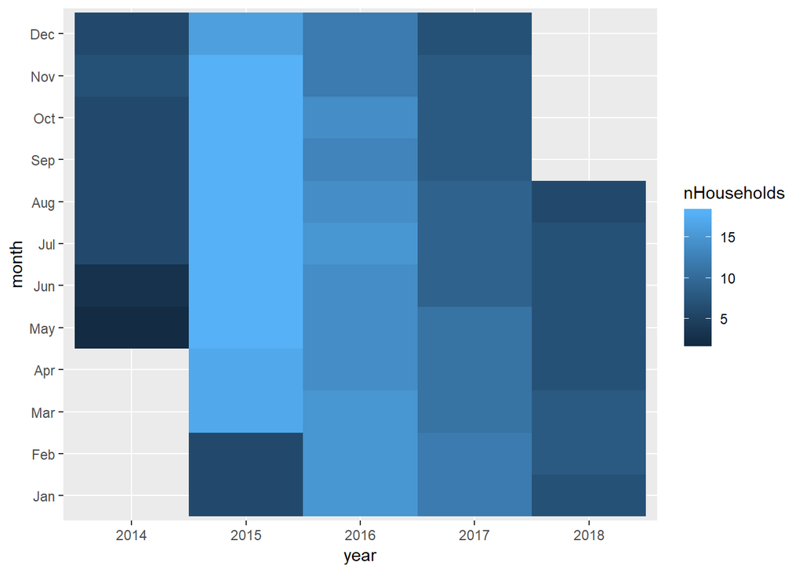

Figure 2.1: Count of observed households by year and month

```r
ggplot2::ggplot(t, aes(x = year, y = month, fill = nHouseholds)) + geom_tile()
```

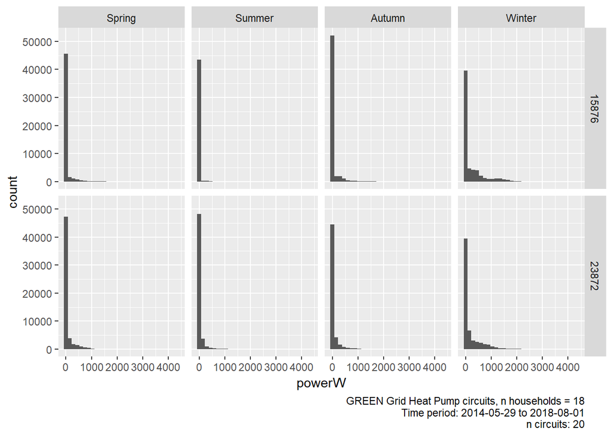

Figure 2.2: Histogram mean hourly power demand for Heat Pumps by season and location

```r
hpCap <- paste0("GREEN Grid Heat Pump circuits, n households = ", uniqueN(hpDT$id),
    "\n Time period: ", min(lubridate::date(hpDT$r_dateTimeLocal)), " to ",
    max(lubridate::date(hpDT$r_dateTimeLocal)))

ggplot2::ggplot(hpDT, aes(x = powerW)) + geom_histogram() + facet_grid(location ~
    season) + labs(caption = paste0(hpCap, "\n n circuits: ", uniqueN(hpDT$circuit)))
```

Figure 2.3 shows same plot but only for power > 0 W (i.e. on standby or heating) and only for the circuits BA suggests we include (all but 2 - see Table 2.3). Does this look right?

```r
dt <- hpDT[powerW > 0 & ba_includeCircuit == 1]
message("Check min power: ", min(dt$powerW))
```

```
## Check min power: 0.0166666666666667
```

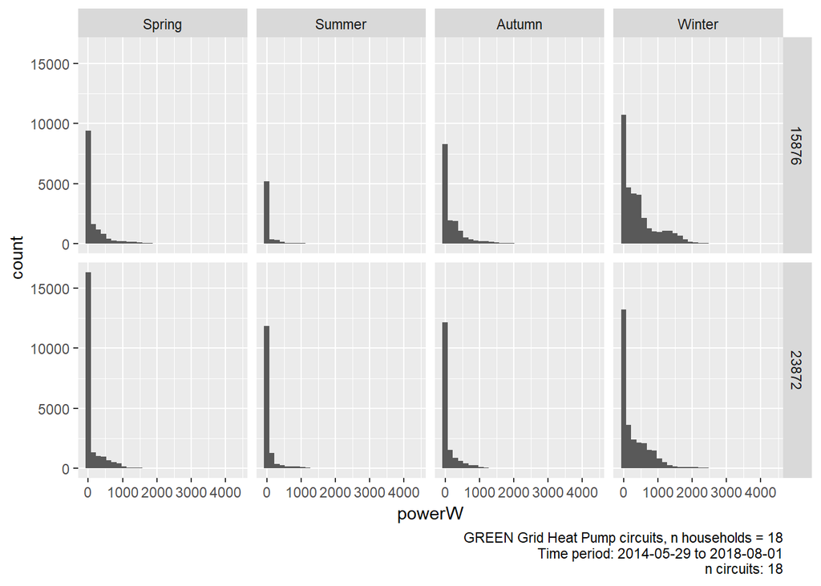

Figure 2.3: Histogram mean hourly power demand for Heat Pumps by season and location

```r
ggplot2::ggplot(dt, aes(x = powerW)) + geom_histogram() + facet_grid(location ~
    season) + labs(caption = paste0(hpCap, "\n n circuits: ", uniqueN(dt$circuit)))
```

Figure 2.4 shows same plot but only for power > 40 W and only for the circuits BA suggests we include. Does this look right?

```r
dt <- hpDT[powerW > 40 & ba_includeCircuit == 1]
message("Check min power: ", min(dt$powerW))
```

```
## Check min power: 40.0005
```

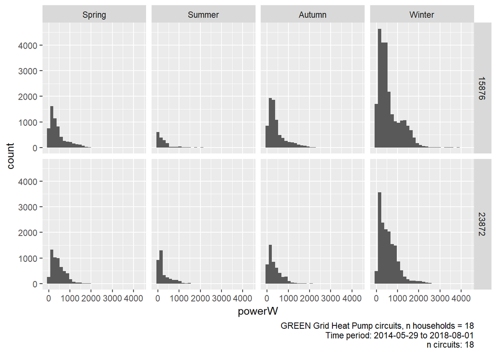

Figure 2.4: Histogram mean hourly power demand for Heat Pumps by season and location

```r
ggplot2::ggplot(dt, aes(x = powerW)) + geom_histogram() + facet_grid(location ~
    season) + labs(caption = paste0(hpCap, "\n n circuits: ", uniqueN(dt$circuit)))
```

Figure 2.5 shows the mean heat pump demand (no power value exclusions) by time of day by season for the circuits BA suggests we include. Does this look right?

Figure 2.5 is important because:

- we converted the incoming UTC dateTime to local (NZT) time -> `r_dateTimeLocal`
- we then created a hh:mm variable from `r_dateTimeLocal` and used that to make this plot
- so if this looks like the right shape for Heat Pump demand then we have made the correct assumptions about the incoming `r_dateTime`

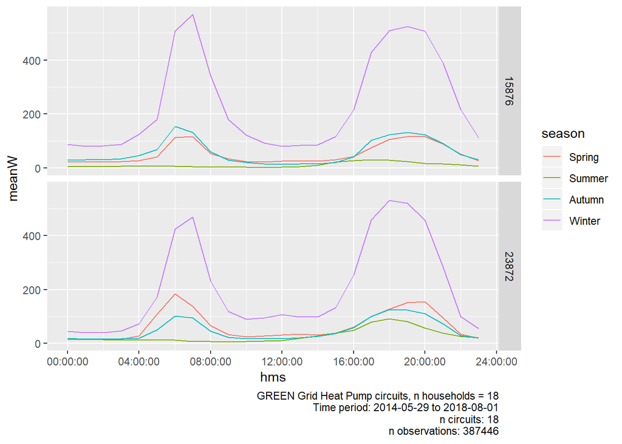

Figure 2.5: Line plot of mean power demand for Heat Pumps by season and location

```r
dt <- hpDT[ba_includeCircuit == 1]

plotDT <- dt[, .(meanW = mean(powerW)), keyby = .(hms, season, location)]

ggplot2::ggplot(plotDT, aes(x = hms, y = meanW, colour = season)) + geom_line() +
    facet_grid(location ~ .) + labs(caption = paste0(hpCap, "\n n circuits: ",
    uniqueN(dt$circuit), "\n n observations: ", nrow(dt[!is.na(powerW)])))
```

Are we seeing some cooling in summer?

We can repeat this plot including only powerW values > 40 W (Figure 2.6). This shows the level of demand *when they are on*. This plot shows some distinct signs of heat pump use in early evenings in summer producing a slightly earlier ‘peak’ than is the case for winter heating. It has to be said however that the plots are quite messy, no doubt due to the small numbers involved.

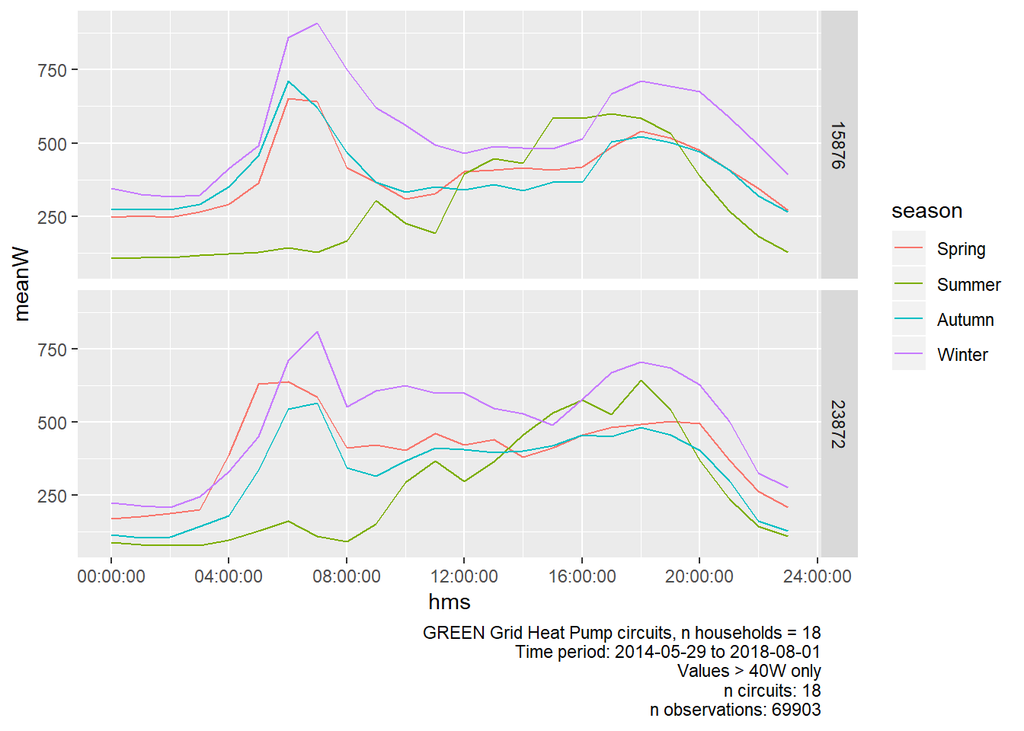

Figure 2.6: Line plot of mean power demand for Heat Pumps by season and location where power > 40W

```r
dt <- hpDT[powerW > 40 & ba_includeCircuit == 1]

plotDT <- dt[, .(meanW = mean(powerW)), keyby = .(hms, season, location)]

ggplot2::ggplot(plotDT, aes(x = hms, y = meanW, colour = season)) + geom_line() +
    facet_grid(location ~ .) + labs(caption = paste0(hpCap, "\n Values > 40W only",
    "\n n circuits: ", uniqueN(dt$circuit), "\n n observations: ", nrow(dt[!is.na(powerW)])))
```

## 2.2 Temperature

### 2.2.1 Data in 2 files

First we load this using the two seperate files.

```r
message("Loading 15876_hourly_all.txt.gz")
```

```
## Loading 15876_hourly_all.txt.gz
```

```r
temp15876DT <- data.table::fread(paste0(myParams$dPath, "15876_hourly_all.txt.gz"))
message("Loading 23872_hourly_all.txt.gz")
```

```
## Loading 23872_hourly_all.txt.gz
```

```r
temp23872DT <- data.table::fread(paste0(myParams$dPath, "23872_hourly_all.txt.gz"))

fixTempData <- function(dt){
  # bunch of stuff we want to do to each dataset
  # fix datetime so it matches the hp data
  dt <- dt[, r_dateTime := lubridate::dmy_hm(`Date(NZST)`, # so we know it's NZT - shame it had to have () in it!
                                                  tz = "Pacific/Auckland")] # just to be sure (if you ran this code in the UK it would set it to UTC by default)


  dt <- dt[, hms := hms::as.hms(r_dateTime)]

  dt <- GREENGridData::addNZSeason(dt)

  dt <- dt[, r_dateTimeLocal := r_dateTime] # for matching
  dt <- dt[, location := Station] # for matching

  return(dt)
}

temp15876DT <- fixTempData(temp15876DT)
message("Some dates failed to parse - which ones?")
```

```
## Some dates failed to parse - which ones?
```

```r
kableExtra::kable(head(temp15876DT[is.na(r_dateTimeLocal), .(Station, `Date(NZST)`, r_dateTimeLocal)]),
                  caption = "Non-parsed dates for location =  15876")
```

Table 2.7: Non-parsed dates for location = 15876

| Station | Date(NZST) | r_dateTimeLocal |
| --- | --- | --- |
| 15876 | 05/10/1997 02:00 | NA |
| 15876 | 04/10/1998 02:00 | NA |
| 15876 | 03/10/1999 02:00 | NA |
| 15876 | 01/10/2000 02:00 | NA |
| 15876 | 07/10/2001 02:00 | NA |
| 15876 | 06/10/2002 02:00 | NA |

```r
temp23872DT <- fixTempData(temp23872DT)
message("Some dates failed to parse - which ones?")
```

```
## Some dates failed to parse - which ones?
```

```r
kableExtra::kable(head(temp23872DT[is.na(r_dateTimeLocal), .(Station, `Date(NZST)`, r_dateTimeLocal)]),
                  caption = "Non-parsed dates for location =  23872")
```

Table 2.7: Non-parsed dates for location = 23872

| Station | Date(NZST) | r_dateTimeLocal |
| --- | --- | --- |
| 23872 | 05/10/2003 02:00 | NA |
| 23872 | 03/10/2004 02:00 | NA |
| 23872 | 02/10/2005 02:00 | NA |
| 23872 | 01/10/2006 02:00 | NA |
| 23872 | 30/09/2007 02:00 | NA |
| 23872 | 28/09/2008 02:00 | NA |

```r
message("Looks like the ones around the DST switches. We hate DST almost as much as we hate timezones.")
```

```
## Looks like the ones around the DST switches. We hate DST almost as much as we hate timezones.
```

Convert the incoming character values to numeric as needed.

```r
# combine the temperature data
tempDT <- rbind(temp15876DT, temp23872DT)

tempDT <- tempDT[, `:=`(meanTemp, as.numeric(`Tmean(C)`))]
message("Note that ", nrow(tempDT[is.na(meanTemp)]), " observations have no Tmean(C) values...")
```

```
## Note that 645 observations have no Tmean(C) values...
```

```r
tempDT <- tempDT[, `:=`(year, lubridate::year(r_dateTime))]
t <- addmargins(with(tempDT[is.na(meanTemp)], table(Station, year)))

kableExtra::kable(t, caption = "Counts of missing temperature observations by location and year (source: 2 files)") %>%
    kable_styling()
```

Table 2.8: Counts of missing temperature observations by location and year (source: 2 files)

|  | 1998 | 2003 | 2004 | 2006 | 2007 | 2008 | 2010 | 2012 | 2014 | 2015 | 2016 | 2018 | Sum |
| --- | --- | --- | --- | --- | --- | --- | --- | --- | --- | --- | --- | --- | --- |
| 15876 | 2 | 53 | 491 | 0 | 0 | 1 | 0 | 1 | 0 | 0 | 3 | 0 | 551 |
| 23872 | 0 | 0 | 0 | 12 | 22 | 0 | 31 | 1 | 1 | 1 | 0 | 26 | 94 |
| Sum | 2 | 53 | 491 | 12 | 22 | 1 | 31 | 2 | 1 | 1 | 3 | 26 | 645 |

```r
message("But it's mostly in years we don't have HP data for?")
```

```
## But it's mostly in years we don't have HP data for?
```

Figure 2.7 shows the mean temperature by time of day by season. Does this look right? The alpha values are suggesting it’s getting warmer…

As above this plot is important. If the shape looks right then we have made the correct assumptions about our incoming dateTime values.

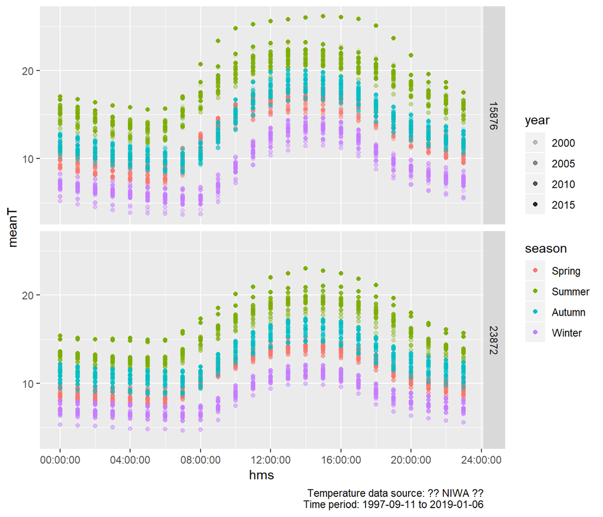

Figure 2.7: Line plot of mean temperature by season and location

```r
plotDT <- tempDT[, .(meanT = mean(meanTemp, na.rm = TRUE)), # crucial otherwise any NA causes the calculation to be NA
                 keyby = .(hms, season, Station, year)]

tempCap <- paste0("Temperature data source: ?? NIWA ??",
                        "\n Time period: ", min(lubridate::date(tempDT$r_dateTimeLocal), na.rm = TRUE),
                        " to ",
                         max(lubridate::date(tempDT$r_dateTimeLocal), na.rm = TRUE)
                  )

ggplot2::ggplot(plotDT, aes(x = hms, y = meanT, colour = season, alpha = year)) +
  geom_point() +
  facet_grid(Station ~ .) +
  labs(caption = tempCap)
```

### 2.2.2 Both datasets in 1 file

Now test the single temperature file which contains both.

```r
message("Loading alltemp_hourly.csv.gz")
```

```
## Loading alltemp_hourly.csv.gz
```

```r
tempBothDT <- data.table::fread(paste0(myParams$dPath, "alltemp_hourly.csv.gz"))

kableExtra::kable(head(tempBothDT),
                  caption = "Head:  alltemp_hourly.csv.gz before processing")
```

Table 2.9: Head: alltemp_hourly.csv.gz before processing

| V1 | location | r_dateTime | Tmax_C | Tmin_C | Tmean_C | location |
| --- | --- | --- | --- | --- | --- | --- |
| 1 | 15876 | 1997-09-11 17:00:00 | 14.4 | 13.8 | 14.2 | 15876 |
| 2 | 15876 | 1997-09-11 18:00:00 | 14.3 | 12.8 | 13.8 | 15876 |
| 3 | 15876 | 1997-09-11 19:00:00 | 12.9 | 12.1 | 12.5 | 15876 |
| 4 | 15876 | 1997-09-11 20:00:00 | 12.4 | 11.9 | 12.2 | 15876 |
| 5 | 15876 | 1997-09-11 21:00:00 | 11.9 | 11.0 | 11.5 | 15876 |
| 6 | 15876 | 1997-09-11 22:00:00 | 11.7 | 11.1 | 11.4 | 15876 |

```r
tempBothDT <- tempBothDT[, r_dateTimeLocal := lubridate::ymd_hms(r_dateTime, # looks like NZT as the first rows it match the first few rows of temp15876DT
                                                  tz = "Pacific/Auckland")] # just to be sure (if you ran this code in the UK it would set it to UTC by default)


  tempBothDT <- tempBothDT[, hms := hms::as.hms(r_dateTimeLocal)]

  tempBothDT <- GREENGridData::addNZSeason(tempBothDT)

tempBothDT$V1 <- NULL
tempBothDT <- tempBothDT[, meanTemp := Tmean_C]


kableExtra::kable(head(tempBothDT),
                  caption = "Head:  alltemp_hourly.csv.gz after processing")
```

Table 2.9: Head: alltemp_hourly.csv.gz after processing

| location | r_dateTime | Tmax_C | Tmin_C | Tmean_C | location | r_dateTimeLocal | hms | season | meanTemp |
| --- | --- | --- | --- | --- | --- | --- | --- | --- | --- |
| 15876 | 1997-09-11 17:00:00 | 14.4 | 13.8 | 14.2 | 15876 | 1997-09-11 17:00:00 | 17:00:00 | Spring | 14.2 |
| 15876 | 1997-09-11 18:00:00 | 14.3 | 12.8 | 13.8 | 15876 | 1997-09-11 18:00:00 | 18:00:00 | Spring | 13.8 |
| 15876 | 1997-09-11 19:00:00 | 12.9 | 12.1 | 12.5 | 15876 | 1997-09-11 19:00:00 | 19:00:00 | Spring | 12.5 |
| 15876 | 1997-09-11 20:00:00 | 12.4 | 11.9 | 12.2 | 15876 | 1997-09-11 20:00:00 | 20:00:00 | Spring | 12.2 |
| 15876 | 1997-09-11 21:00:00 | 11.9 | 11.0 | 11.5 | 15876 | 1997-09-11 21:00:00 | 21:00:00 | Spring | 11.5 |
| 15876 | 1997-09-11 22:00:00 | 11.7 | 11.1 | 11.4 | 15876 | 1997-09-11 22:00:00 | 22:00:00 | Spring | 11.4 |

Again, this plot tells us if our dateTime assumptions are correct.

```r
# combine the temperature data

message("Note that ", nrow(tempBothDT[is.na(meanTemp)]), " observations have no Tmean(C) values...")
```

```
## Note that 634 observations have no Tmean(C) values...
```

```r
tempBothDT <- tempBothDT[, year := lubridate::year(r_dateTime)]
t <- addmargins(with(tempBothDT[is.na(meanTemp)], table(location,year)))

kableExtra::kable(t, caption = "Counts of missing temperature observations by location and year (source: 1 file)") %>%
  kable_styling()
```

Table 2.10: Counts of missing temperature observations by location and year (source: 1 file)

|  | 1998 | 2003 | 2004 | 2006 | 2007 | 2008 | 2010 | 2012 | 2014 | 2015 | 2016 | 2018 | Sum |
| --- | --- | --- | --- | --- | --- | --- | --- | --- | --- | --- | --- | --- | --- |
| 15876 | 2 | 53 | 491 | 0 | 0 | 1 | 0 | 1 | 0 | 0 | 3 | 0 | 551 |
| 23872 | 0 | 0 | 0 | 12 | 11 | 0 | 31 | 1 | 1 | 1 | 0 | 26 | 83 |
| Sum | 2 | 53 | 491 | 12 | 11 | 1 | 31 | 2 | 1 | 1 | 3 | 26 | 634 |

```r
message("But it's mostly in years we don't have HP data for?")
```

```
## But it's mostly in years we don't have HP data for?
```

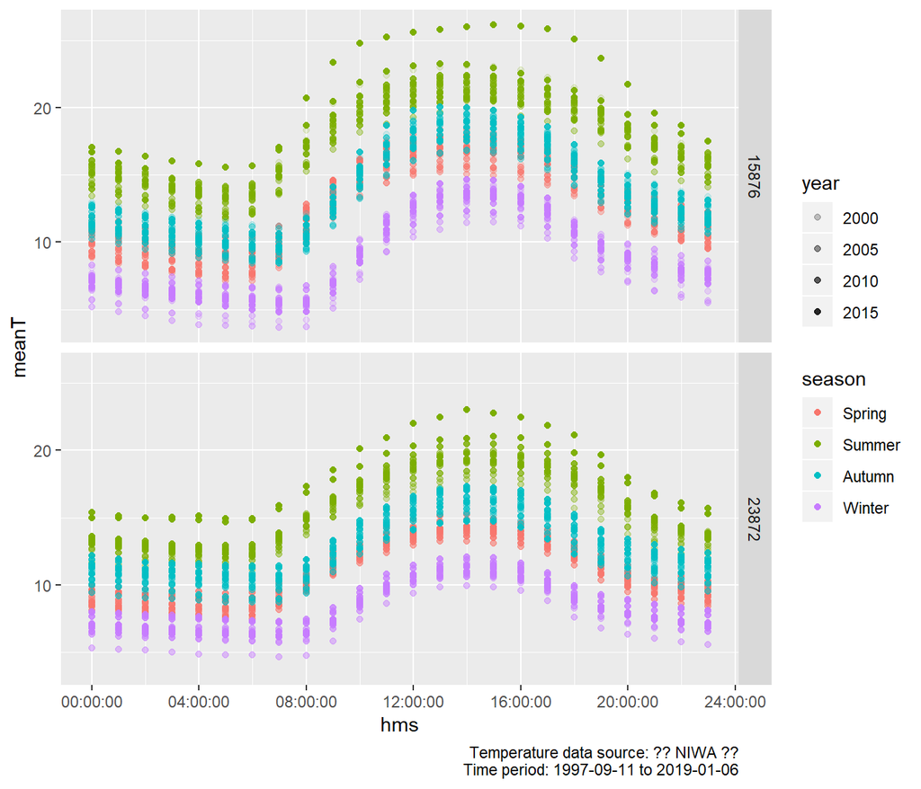

Figure 2.8: Line plot of mean temperature by season and location

```r
plotDT <- tempBothDT[, .(meanT = mean(meanTemp, na.rm = TRUE)), # crucial otherwise any NA causes the calculation to be NA
                 keyby = .(hms, season, location, year)]

tempCap <- paste0("Temperature data source: ?? NIWA ??",
                        "\n Time period: ", min(lubridate::date(tempBothDT$r_dateTimeLocal), na.rm = TRUE),
                        " to ",
                         max(lubridate::date(tempBothDT$r_dateTimeLocal), na.rm = TRUE)
                  )

ggplot2::ggplot(plotDT, aes(x = hms, y = meanT, colour = season, alpha = year)) +
  geom_point() +
  facet_grid(location ~ .) +
  labs(caption = tempCap)
```

Now we can directly compare the two sources of temperature data to see if they match. Figure 2.9 does this by linking the two files on `r_dateTimeLocal` and `location` and then plotting the temperature values from each source.

```r
message("N rows of 2 files merged: ", nrow(tempDT))
```

```
## N rows of 2 files merged: 328719
```

```r
message("N rows of alltemp_hourly.csv.gz : ", nrow(tempBothDT))
```

```
## N rows of alltemp_hourly.csv.gz : 324465
```

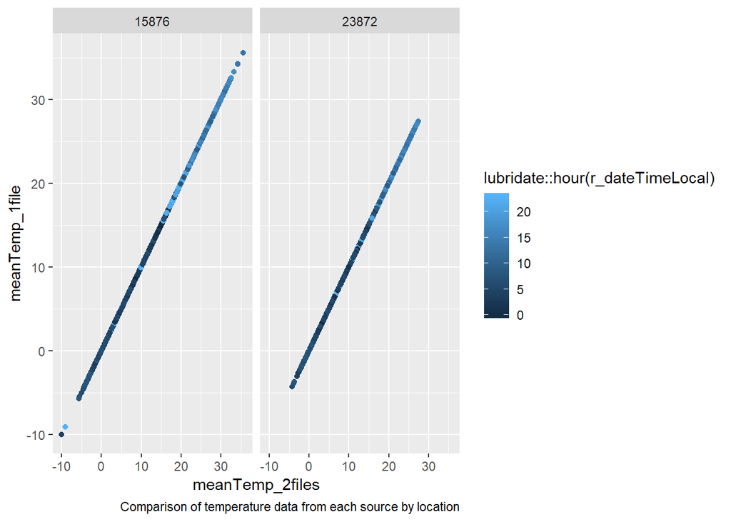

Figure 2.9: Comparison of temperature data from each source by location

```r
tempDT <- tempDT[, `:=`(source, "Separate files")]
tempBothDT <- tempBothDT[, `:=`(source, "alltemp_hourly.csv.gz")]

# let's try just comparing dates

t2fdt <- tempDT[, .(dateTime_char_2f = `Date(NZST)`, r_dateTimeLocal, meanTemp_2files = meanTemp,
    location, hms_2files = hms)]
setkey(t2fdt, r_dateTimeLocal, location)

t1fdt <- tempBothDT[, .(dateTime_char_1f = r_dateTime, r_dateTimeLocal, meanTemp_1file = meanTemp,
    location, hms_1file = hms)]
setkey(t1fdt, r_dateTimeLocal, location)

dt <- t2fdt[t1fdt]  # merge on dateTimeLocal & location

ggplot2::ggplot(dt[!is.na(r_dateTimeLocal)], aes(x = meanTemp_2files, y = meanTemp_1file,
    colour = lubridate::hour(r_dateTimeLocal))) + geom_point() + facet_grid(. ~
    location) + labs(caption = "Comparison of temperature data from each source by location")
```

```r
# so some of them match but not all
dt <- dt[, `:=`(diffTemp, meanTemp_2files - meanTemp_1file)]
```

Bang on. As we can see, it makes no differnce which temperture data is used.

## 2.3 Link the HP and temperature data

So it looks like the date times are OK for both the HP and temperature data and either version of the temperature data is OK too. Now let’s try to link the temperature data derivd from the 2 files to the heat pump data using station and r_dateTimeLocal.

```r
tempDT <- data.table::setkey(tempDT, location, r_dateTimeLocal)  # set key to link
tempDT <- tempDT[, `:=`(hour, lubridate::hour(r_dateTimeLocal))]

hpDT <- data.table::setkey(hpDT, location, r_dateTimeLocal)
hpDT <- hpDT[, `:=`(hour, lubridate::hour(r_dateTimeLocal))]

# remove the NA dateTimes before we do
tempDTclean <- tempDT[!is.na(r_dateTimeLocal)]

linkedDT <- tempDTclean[hpDT]  # this will add each row of tempDT to the end of each relevant row of hpDT
```

Now, because we did *not* match on `hour` we can see if anything failed to match up in terms of time of day. There are (Table 2.11) but it looks like they are to do with the missing temperature data as the NAs in the temperature columns (see Table 2.12).

```r
t <- addmargins(with(linkedDT, table(hour, i.hour, useNA = "always")))

kableExtra::kable(t, caption = "Counts of hours from each source") %>% kable_styling()
```

Table 2.11: Counts of hours from each source

|  | 0 | 1 | 2 | 3 | 4 | 5 | 6 | 7 | 8 | 9 | 10 | 11 | 12 | 13 | 14 | 15 | 16 | 17 | 18 | 19 | 20 | 21 | 22 | 23 | NA | Sum |
| --- | --- | --- | --- | --- | --- | --- | --- | --- | --- | --- | --- | --- | --- | --- | --- | --- | --- | --- | --- | --- | --- | --- | --- | --- | --- | --- |
| 0 | 18180 | 0 | 0 | 0 | 0 | 0 | 0 | 0 | 0 | 0 | 0 | 0 | 0 | 0 | 0 | 0 | 0 | 0 | 0 | 0 | 0 | 0 | 0 | 0 | 0 | 18180 |
| 1 | 0 | 18183 | 0 | 0 | 0 | 0 | 0 | 0 | 0 | 0 | 0 | 0 | 0 | 0 | 0 | 0 | 0 | 0 | 0 | 0 | 0 | 0 | 0 | 0 | 0 | 18183 |
| 2 | 0 | 0 | 18133 | 0 | 0 | 0 | 0 | 0 | 0 | 0 | 0 | 0 | 0 | 0 | 0 | 0 | 0 | 0 | 0 | 0 | 0 | 0 | 0 | 0 | 0 | 18133 |
| 3 | 0 | 0 | 0 | 18127 | 0 | 0 | 0 | 0 | 0 | 0 | 0 | 0 | 0 | 0 | 0 | 0 | 0 | 0 | 0 | 0 | 0 | 0 | 0 | 0 | 0 | 18127 |
| 4 | 0 | 0 | 0 | 0 | 18177 | 0 | 0 | 0 | 0 | 0 | 0 | 0 | 0 | 0 | 0 | 0 | 0 | 0 | 0 | 0 | 0 | 0 | 0 | 0 | 0 | 18177 |
| 5 | 0 | 0 | 0 | 0 | 0 | 18188 | 0 | 0 | 0 | 0 | 0 | 0 | 0 | 0 | 0 | 0 | 0 | 0 | 0 | 0 | 0 | 0 | 0 | 0 | 0 | 18188 |
| 6 | 0 | 0 | 0 | 0 | 0 | 0 | 18186 | 0 | 0 | 0 | 0 | 0 | 0 | 0 | 0 | 0 | 0 | 0 | 0 | 0 | 0 | 0 | 0 | 0 | 0 | 18186 |
| 7 | 0 | 0 | 0 | 0 | 0 | 0 | 0 | 18198 | 0 | 0 | 0 | 0 | 0 | 0 | 0 | 0 | 0 | 0 | 0 | 0 | 0 | 0 | 0 | 0 | 0 | 18198 |
| 8 | 0 | 0 | 0 | 0 | 0 | 0 | 0 | 0 | 18203 | 0 | 0 | 0 | 0 | 0 | 0 | 0 | 0 | 0 | 0 | 0 | 0 | 0 | 0 | 0 | 0 | 18203 |
| 9 | 0 | 0 | 0 | 0 | 0 | 0 | 0 | 0 | 0 | 18179 | 0 | 0 | 0 | 0 | 0 | 0 | 0 | 0 | 0 | 0 | 0 | 0 | 0 | 0 | 0 | 18179 |
| 10 | 0 | 0 | 0 | 0 | 0 | 0 | 0 | 0 | 0 | 0 | 18194 | 0 | 0 | 0 | 0 | 0 | 0 | 0 | 0 | 0 | 0 | 0 | 0 | 0 | 0 | 18194 |
| 11 | 0 | 0 | 0 | 0 | 0 | 0 | 0 | 0 | 0 | 0 | 0 | 18158 | 0 | 0 | 0 | 0 | 0 | 0 | 0 | 0 | 0 | 0 | 0 | 0 | 0 | 18158 |
| 12 | 0 | 0 | 0 | 0 | 0 | 0 | 0 | 0 | 0 | 0 | 0 | 0 | 18171 | 0 | 0 | 0 | 0 | 0 | 0 | 0 | 0 | 0 | 0 | 0 | 0 | 18171 |
| 13 | 0 | 0 | 0 | 0 | 0 | 0 | 0 | 0 | 0 | 0 | 0 | 0 | 0 | 18186 | 0 | 0 | 0 | 0 | 0 | 0 | 0 | 0 | 0 | 0 | 0 | 18186 |
| 14 | 0 | 0 | 0 | 0 | 0 | 0 | 0 | 0 | 0 | 0 | 0 | 0 | 0 | 0 | 18193 | 0 | 0 | 0 | 0 | 0 | 0 | 0 | 0 | 0 | 0 | 18193 |
| 15 | 0 | 0 | 0 | 0 | 0 | 0 | 0 | 0 | 0 | 0 | 0 | 0 | 0 | 0 | 0 | 18207 | 0 | 0 | 0 | 0 | 0 | 0 | 0 | 0 | 0 | 18207 |
| 16 | 0 | 0 | 0 | 0 | 0 | 0 | 0 | 0 | 0 | 0 | 0 | 0 | 0 | 0 | 0 | 0 | 18220 | 0 | 0 | 0 | 0 | 0 | 0 | 0 | 0 | 18220 |
| 17 | 0 | 0 | 0 | 0 | 0 | 0 | 0 | 0 | 0 | 0 | 0 | 0 | 0 | 0 | 0 | 0 | 0 | 18233 | 0 | 0 | 0 | 0 | 0 | 0 | 0 | 18233 |
| 18 | 0 | 0 | 0 | 0 | 0 | 0 | 0 | 0 | 0 | 0 | 0 | 0 | 0 | 0 | 0 | 0 | 0 | 0 | 18234 | 0 | 0 | 0 | 0 | 0 | 0 | 18234 |
| 19 | 0 | 0 | 0 | 0 | 0 | 0 | 0 | 0 | 0 | 0 | 0 | 0 | 0 | 0 | 0 | 0 | 0 | 0 | 0 | 18235 | 0 | 0 | 0 | 0 | 0 | 18235 |
| 20 | 0 | 0 | 0 | 0 | 0 | 0 | 0 | 0 | 0 | 0 | 0 | 0 | 0 | 0 | 0 | 0 | 0 | 0 | 0 | 0 | 18229 | 0 | 0 | 0 | 0 | 18229 |
| 21 | 0 | 0 | 0 | 0 | 0 | 0 | 0 | 0 | 0 | 0 | 0 | 0 | 0 | 0 | 0 | 0 | 0 | 0 | 0 | 0 | 0 | 18227 | 0 | 0 | 0 | 18227 |
| 22 | 0 | 0 | 0 | 0 | 0 | 0 | 0 | 0 | 0 | 0 | 0 | 0 | 0 | 0 | 0 | 0 | 0 | 0 | 0 | 0 | 0 | 0 | 18209 | 0 | 0 | 18209 |
| 23 | 0 | 0 | 0 | 0 | 0 | 0 | 0 | 0 | 0 | 0 | 0 | 0 | 0 | 0 | 0 | 0 | 0 | 0 | 0 | 0 | 0 | 0 | 0 | 18141 | 0 | 18141 |
| NA | 192 | 198 | 244 | 198 | 198 | 198 | 211 | 200 | 197 | 221 | 209 | 228 | 219 | 209 | 204 | 191 | 184 | 184 | 184 | 188 | 187 | 187 | 185 | 189 | 0 | 4805 |
| Sum | 18372 | 18381 | 18377 | 18325 | 18375 | 18386 | 18397 | 18398 | 18400 | 18400 | 18403 | 18386 | 18390 | 18395 | 18397 | 18398 | 18404 | 18417 | 18418 | 18423 | 18416 | 18414 | 18394 | 18330 | 0 | 441396 |

```r
t <- head(linkedDT[is.na(hour)])
kableExtra::kable(t, caption = "Rows of data where hour (from temperature data file) = NA") %>%
    kable_styling()
```

Table 2.12: Rows of data where hour (from temperature data file) = NA

| Station | Date(NZST) | Tmax(C) | Period(Hrs) | Tmin(C) | Period(Hrs).1 | Tgmin(C) | Period(Hrs).2 | Tmean(C) | RHmean(%) | Period(Hrs).3 | Freq | r_dateTime | hms | season | r_dateTimeLocal | location | meanTemp | year | source | hour | i.r_dateTime | powerW | circuit | id | r_dateTimeChar | i.hms | i.season | ej_includeCircuit | ba_includeCircuit | … |
| --- | --- | --- | --- | --- | --- | --- | --- | --- | --- | --- | --- | --- | --- | --- | --- | --- | --- | --- | --- | --- | --- | --- | --- | --- | --- | --- | --- | --- | --- | --- |
| NA | NA | NA | NA | NA | NA | NA | NA | NA | NA | NA | NA | NA | NA | NA | 2015-04-05 02:00:00 | 15876 | NA | NA | NA | NA | 2015-04-04 13:00:00 | 0.00000 | Heat Pump$4204 | rf_31 | 2015-04-04 13:00:00 | 02:00:00 | Autumn | 1 | 1 | … |
| NA | NA | NA | NA | NA | NA | NA | NA | NA | NA | NA | NA | NA | NA | NA | 2015-04-05 02:00:00 | 15876 | NA | NA | NA | NA | 2015-04-04 13:00:00 | 0.00000 | Heat Pump$4223 | rf_34 | 2015-04-04 13:00:00 | 02:00:00 | Autumn | 1 | 1 | … |
| NA | NA | NA | NA | NA | NA | NA | NA | NA | NA | NA | NA | NA | NA | NA | 2015-04-05 02:00:00 | 15876 | NA | NA | NA | NA | 2015-04-04 13:00:00 | 0.20000 | Heat Pump$4124 | rf_35 | 2015-04-04 13:00:00 | 02:00:00 | Autumn | 1 | 1 | … |
| NA | NA | NA | NA | NA | NA | NA | NA | NA | NA | NA | NA | NA | NA | NA | 2015-04-05 02:00:00 | 15876 | NA | NA | NA | NA | 2015-04-04 13:00:00 | 0.00000 | Heat Pump$4154 | rf_44 | 2015-04-04 13:00:00 | 02:00:00 | Autumn | 1 | 1 | … |
| NA | NA | NA | NA | NA | NA | NA | NA | NA | NA | NA | NA | NA | NA | NA | 2015-05-29 09:00:00 | 15876 | NA | NA | NA | NA | 2015-05-28 21:00:00 | 225.59650 | Heat Pump$4204 | rf_31 | 2015-05-28 21:00:00 | 09:00:00 | Autumn | 1 | 1 | … |
| NA | NA | NA | NA | NA | NA | NA | NA | NA | NA | NA | NA | NA | NA | NA | 2015-05-29 09:00:00 | 15876 | NA | NA | NA | NA | 2015-05-28 21:00:00 | 31.88967 | Heat Pump$4196 | rf_32 | 2015-05-28 21:00:00 | 09:00:00 | Autumn | 1 | 1 | … |

# 3 Test relationship between temperature and heat pump demand (BA filtered data)

First we just plot all the hourly data for demand vs mean temperature (Figure 3.1).

```r
baFilteredDT <- linkedDT[ba_includeCircuit == 1 & !is.na(meanTemp)]


t <- baFilteredDT[, .(meanW = mean(powerW), minW = min(powerW), maxW = max(powerW),
    nObs = .N, nCircuits = uniqueN(circuit), nHouseholds = uniqueN(id)), keyby = .(location)]

kableExtra::kable(t, caption = "Summary power demand statistics (all data)") %>%
    kable_styling()
```

Table 3.1: Summary power demand statistics (all data)

| location | meanW | minW | maxW | nObs | nCircuits | nHouseholds |
| --- | --- | --- | --- | --- | --- | --- |
| 15876 | 99.47134 | 0 | 4342.474 | 216263 | 11 | 11 |
| 23872 | 90.76957 | 0 | 3145.554 | 167444 | 7 | 7 |

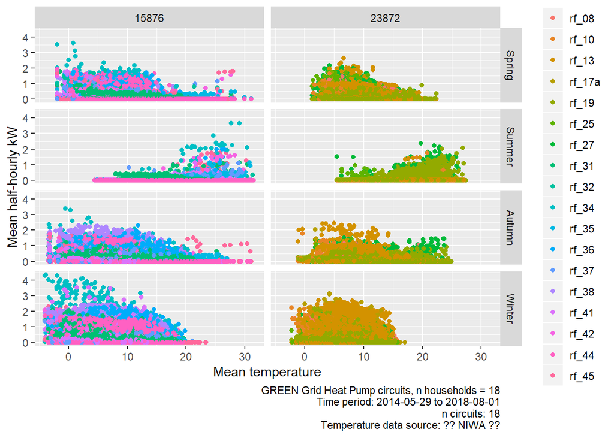

Figure 3.1: Plots of temperature vs demand by season and location

```r
hpCap <- paste0("GREEN Grid Heat Pump circuits, n households = ", uniqueN(baFilteredDT$id),
    "\n Time period: ", min(lubridate::date(baFilteredDT$r_dateTimeLocal)),
    " to ", max(lubridate::date(baFilteredDT$r_dateTimeLocal)), "\n n circuits: ",
    uniqueN(baFilteredDT$circuit))

tempCap <- paste0("Temperature data source: ?? NIWA ??")

combinedCaption <- paste0(hpCap, "\n", tempCap)

ggplot2::ggplot(baFilteredDT[!is.na(meanTemp)], aes(x = meanTemp, y = powerW/1000,
    colour = id)) + geom_point() + facet_grid(season ~ location) + labs(caption = combinedCaption,
    x = "Mean temperature", y = "Mean half-hourly kW")
```

That doesn’t tell us a lot - although these is indeed a suggestion of their use for cooling in summer in both locations by some households. This should remind us that this analysis is based on a *very small* sample of households. So let’s try to re-create the binned box plots. In this case it is not helpful to distinguish between households but we should be aware that the patterns we see may be driven by just one or two households’ behaviour.

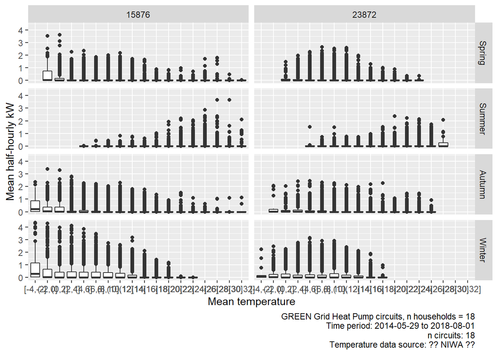

Figure 3.2: Box plots of temperature vs demand by season and location

```r
ggplot2::ggplot(linkedDT[!is.na(meanTemp)],
                         mapping = aes(x = meanTemp, y = powerW/1000)) +
  geom_boxplot(aes(cut_width(meanTemp,
                             width = 2, # change the width to get 'wider' bins
                             boundary = 0)))  +
  facet_grid(season ~ location) +
  labs(caption = combinedCaption,
       x = "Mean temperature",
       y = "Mean half-hourly kW")
```

Figure 3.2 shows binned box plots of power against demand and suggest more clearly that there is a cooling effect for households in summer - especially in 15876. Or perhaps we should more accurately say there is evidence of a summer cooling effect in the 11 (!) households who live in 15876. And who would base a claim on that many households?

Anyway, just for good measure lets try to re-create the U shaped plots Emily produced by ignoring season.

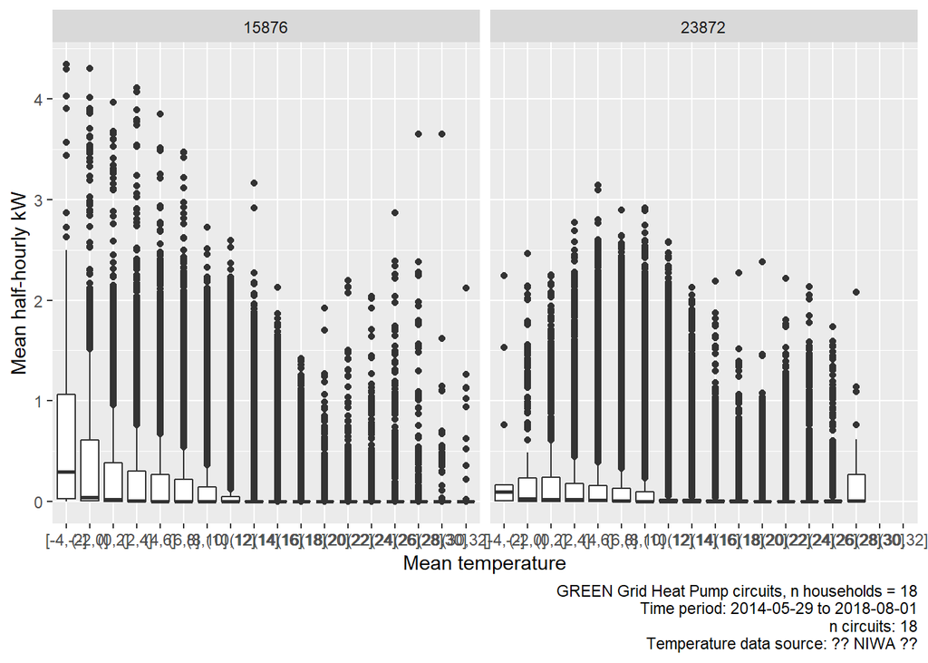

```r
ggplot2::ggplot(linkedDT[!is.na(meanTemp)], mapping = aes(x = meanTemp, y = powerW/1000)) +
  geom_boxplot(aes(cut_width(meanTemp,
                             width = 2, # change the width to get 'wider' bins
                             boundary = 0)))  +
  facet_grid(. ~ location) +
  labs(caption = combinedCaption,
       x = "Mean temperature",
       y = "Mean half-hourly kW")
```

# 4 Test relationship between temperature and heat pump demand (EJ filtered data)

Notwithstanding the previous argument re data exclusion, in this section we test Emily’s suggestion to only keep heat pump data where power > 40 for the circuits defined in `Ä“j_includeCircuit` (see Table 2.3).

First we just plot all the hourly data for demand vs mean temperature (Figure 4.1).

```r
ejFilteredDT <- linkedDT[powerW > 40 & ej_includeCircuit == 1 & !is.na(meanTemp)]

t <- ejFilteredDT[, .(meanW = mean(powerW), minW = min(powerW), maxW = max(powerW),
    nObs = .N, nCircuits = uniqueN(circuit), nHouseholds = uniqueN(id)), keyby = .(location)]

kableExtra::kable(t, caption = "Summary power demand staistics (filtered)") %>%
    kable_styling()
```

Table 4.1: Summary power demand staistics (filtered)

| location | meanW | minW | maxW | nObs | nCircuits | nHouseholds |
| --- | --- | --- | --- | --- | --- | --- |
| 15876 | 532.1126 | 40.0005 | 4342.474 | 39840 | 11 | 11 |
| 23872 | 608.7093 | 40.0305 | 3145.554 | 19053 | 6 | 6 |

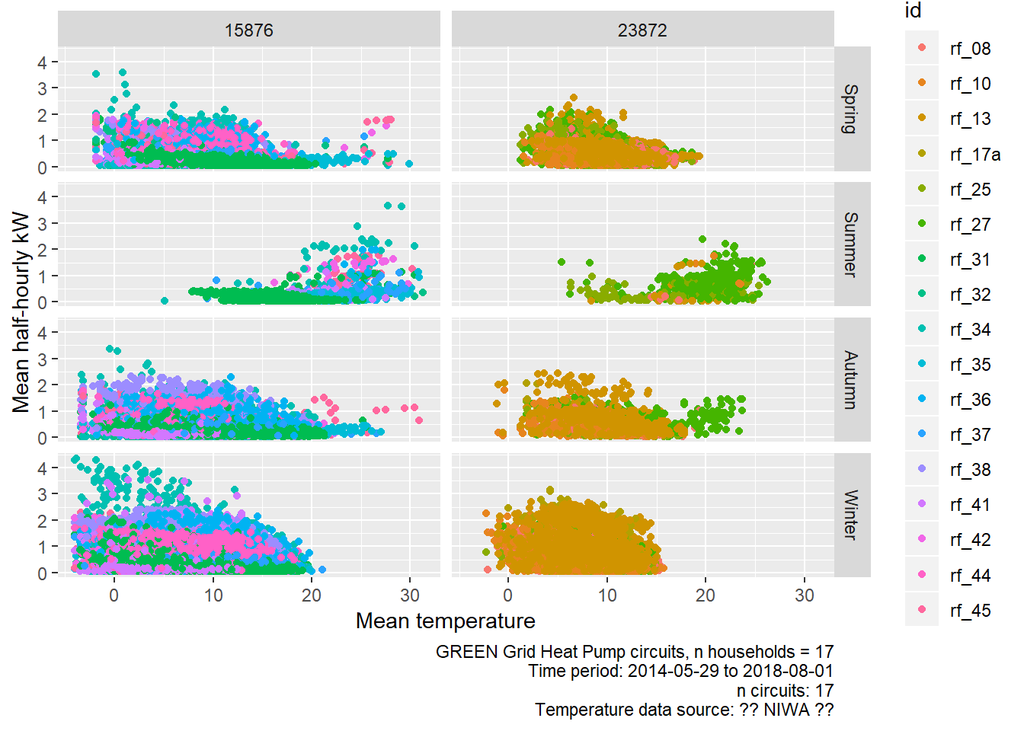

Figure 4.1: Plots of temperature vs demand by season and location

```r
hpCap <- paste0("GREEN Grid Heat Pump circuits, n households = ", uniqueN(ejFilteredDT$id),
    "\n Time period: ", min(lubridate::date(ejFilteredDT$r_dateTimeLocal)),
    " to ", max(lubridate::date(ejFilteredDT$r_dateTimeLocal)), "\n n circuits: ",
    uniqueN(ejFilteredDT$circuit))

tempCap <- paste0("Temperature data source: ?? NIWA ??")

combinedCaption <- paste0(hpCap, "\n", tempCap)

ggplot2::ggplot(ejFilteredDT, aes(x = meanTemp, y = powerW/1000, colour = id)) +
    geom_point() + facet_grid(season ~ location) + labs(caption = combinedCaption,
    x = "Mean temperature", y = "Mean half-hourly kW")
```

Again, that doesn’t tell us a lot - although these is indeed a suggestion of their use for cooling in summer in both locations. So let’s re-try to create the binned box plots.

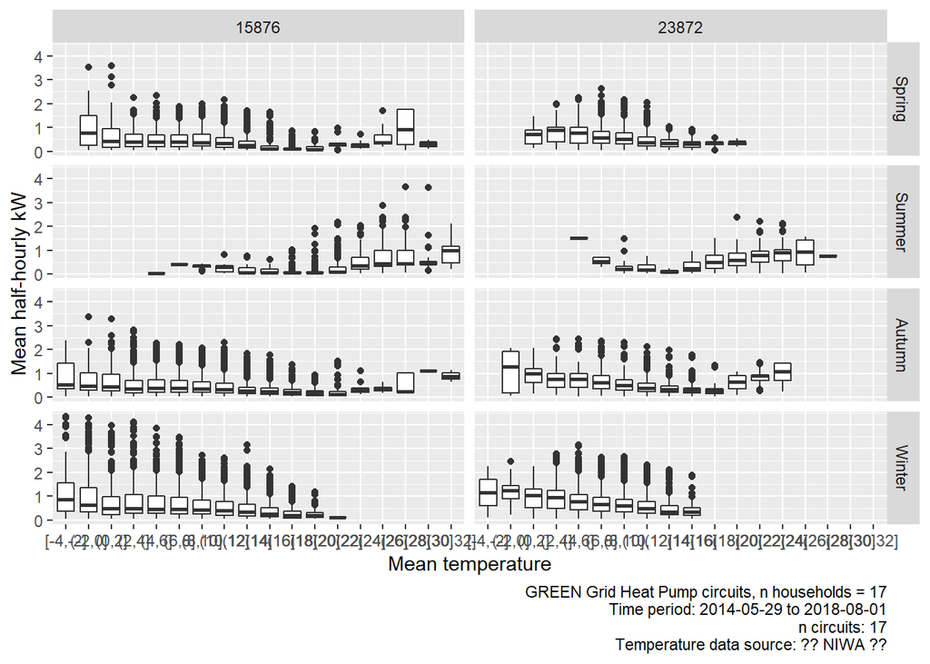

Figure 4.2: Box plots of temperature vs demand by season and location

```r
ggplot2::ggplot(ejFilteredDT, mapping = aes(x = meanTemp, y = powerW/1000)) +
  geom_boxplot(aes(cut_width(meanTemp,
                             width = 2, # change the width to get 'wider' bins
                             boundary = 0)))  +
  facet_grid(season ~ location) +
  labs(caption = combinedCaption,
       x = "Mean temperature",
       y = "Mean half-hourly kW")
```

Figure 4.2 shows binned box plots of power against demand. As we would expect, the plot suggests more clearly that there is a cooling effect for households in summer when we remove 0 and power < 40 W values.

Anyway, lets again try to re-create the U shaped plots Emily produced by ignoring season.

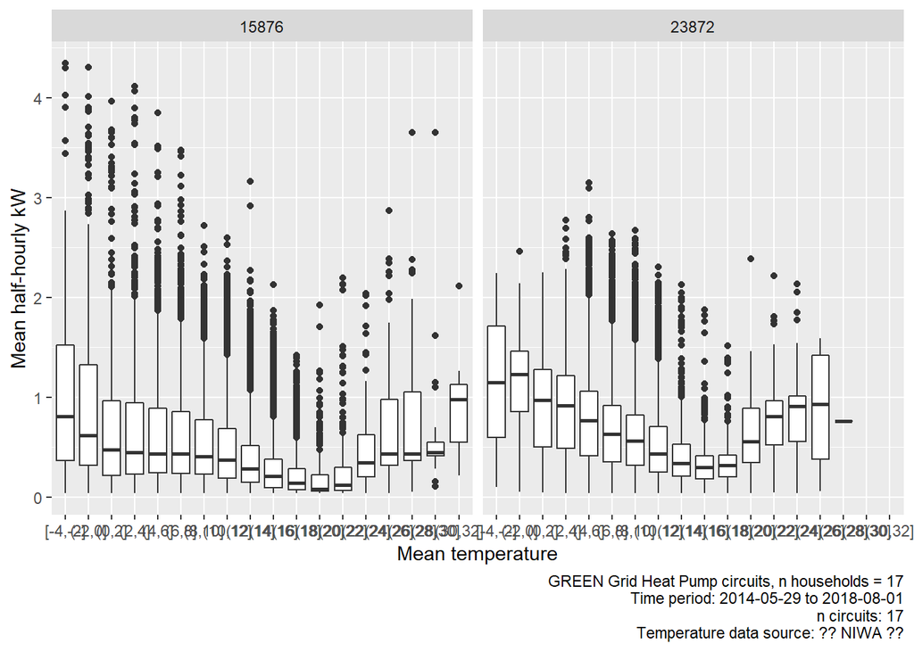

```r
ggplot2::ggplot(ejFilteredDT, mapping = aes(x = meanTemp, y = powerW/1000)) +
  geom_boxplot(aes(cut_width(meanTemp,
                             width = 2, # change the width to get 'wider' bins
                             boundary = 0)))  +
  facet_grid(. ~ location) +
  labs(caption = combinedCaption,
       x = "Mean temperature",
       y = "Mean half-hourly kW")
```

The increase in demand for power as the temperature rises is now clearer.

> But this is fairly obvious since we are just looking at the households who responded to the temperature changes…

# 5 Modelling

## 5.1 Model for all houses in sample (disregardaring location)

Here I am trying to attempt making a quadratic model using the *whole* temperature range.

```r
polyTemp <- poly(ejFilteredDT$meanTemp, 2)
lmTemp <- lm(ejFilteredDT$powerW ~ polyTemp)  # quadratic - TOTAL DATA\
summary(lmTemp)
```

```
##
## Call:
## lm(formula = ejFilteredDT$powerW ~ polyTemp)
##
## Residuals:
##    Min     1Q Median     3Q    Max
## -962.2 -310.6 -126.9  217.3 3366.3
##
## Coefficients:
##               Estimate Std. Error t value Pr(>|t|)
## (Intercept)    556.893      1.878  296.55   <2e-16 ***
## polyTemp1   -29393.162    455.726  -64.50   <2e-16 ***
## polyTemp2     7257.168    455.726   15.92   <2e-16 ***
## ---
## Signif. codes:  0 '***' 0.001 '**' 0.01 '*' 0.05 '.' 0.1 ' ' 1
##
## Residual standard error: 455.7 on 58890 degrees of freedom
## Multiple R-squared:  0.06972,    Adjusted R-squared:  0.06969
## F-statistic:  2207 on 2 and 58890 DF,  p-value: < 2.2e-16
```

But I realise I can’t use each point to model the overall trend - need to use mean or median powerW at each temperature. EDIT: wait I think I can I just have to use geom_smooth() or something instead of points duh.

So here I’ve made a table with the temp, mean power for that temp, and median power for that temp which can be used to model the overall trend.

```r
createMeanMedianPower <- function(dt, temp, width) {
    newDT <- dt[temp - 0.5 * width <= dt$meanTemp & dt$meanTemp < temp + 0.5 *
        width]
    meanTempMeanPower <- mean(newDT$powerW, na.rm = T)
    meanTempMedianPower <- median(newDT$powerW, na.rm = T)
    return(data.table(temp = temp, meanPowerW = meanTempMeanPower, medianPowerW = meanTempMedianPower))
}

modelDT0 <- rbindlist(lapply(seq(min(ejFilteredDT$meanTemp), max(ejFilteredDT$meanTemp),
    1), function(l) {
    return(createMeanMedianPower(ejFilteredDT, l, 1))
}))
```

Here I am making the linear model part for the mean.

```r
polyTemp <- poly(modelDT0$temp, 2)
lmMeanPowerW <- lm(modelDT0$meanPowerW ~ polyTemp)
summary(lmMeanPowerW)
```

```
##
## Call:
## lm(formula = modelDT0$meanPowerW ~ polyTemp)
##
## Residuals:
##     Min      1Q  Median      3Q     Max
## -195.96 -102.51   23.96   90.56  252.51
##
## Coefficients:
##             Estimate Std. Error t value Pr(>|t|)
## (Intercept)    617.5       19.6  31.499  < 2e-16 ***
## polyTemp1     -549.7      117.6  -4.673 4.81e-05 ***
## polyTemp2     1171.3      117.6   9.959 1.79e-11 ***
## ---
## Signif. codes:  0 '***' 0.001 '**' 0.01 '*' 0.05 '.' 0.1 ' ' 1
##
## Residual standard error: 117.6 on 33 degrees of freedom
## Multiple R-squared:  0.7857, Adjusted R-squared:  0.7728
## F-statistic: 60.51 on 2 and 33 DF,  p-value: 9.129e-12
```

Here I am making the linear model part for the median.

```r
lmMedianPowerW <- lm(modelDT0$medianPowerW ~ polyTemp)
summary(lmMedianPowerW)
```

```
##
## Call:
## lm(formula = modelDT0$medianPowerW ~ polyTemp)
##
## Residuals:
##     Min      1Q  Median      3Q     Max
## -197.49 -106.08  -11.61   79.33  418.69
##
## Coefficients:
##             Estimate Std. Error t value Pr(>|t|)
## (Intercept)   464.38      22.34  20.785  < 2e-16 ***
## polyTemp1    -644.77     134.06  -4.810 3.23e-05 ***
## polyTemp2    1064.69     134.06   7.942 3.69e-09 ***
## ---
## Signif. codes:  0 '***' 0.001 '**' 0.01 '*' 0.05 '.' 0.1 ' ' 1
##
## Residual standard error: 134.1 on 33 degrees of freedom
## Multiple R-squared:  0.7232, Adjusted R-squared:  0.7064
## F-statistic: 43.11 on 2 and 33 DF,  p-value: 6.255e-10
```

Here I am making the fit of the models (both mean and median).

```r
modelDT <- cbind(modelDT0, meanPowerWFit = fitted(lmMeanPowerW), medianPowerWFit = fitted(lmMedianPowerW))
modelDT
```

```
##     temp meanPowerW medianPowerW meanPowerWFit medianPowerWFit
##  1:   -4  1425.9230   1429.13917     1173.4156       1010.4457
##  2:   -3  1044.2993    974.26450     1095.7499        937.5231
##  3:   -2   920.7150    697.08258     1022.1340        868.2816
##  4:   -1   837.5371    605.23133      952.5679        802.7211
##  5:    0   770.4796    579.02833      887.0516        740.8417
##  6:    1   714.2605    530.97450      825.5852        682.6434
##  7:    2   679.2211    497.79350      768.1686        628.1261
##  8:    3   711.0973    529.73425      714.8018        577.2900
##  9:    4   702.9884    511.33975      665.4849        530.1348
## 10:    5   700.3121    527.27008      620.2178        486.6608
## 11:    6   675.9416    520.29225      579.0005        446.8678
## 12:    7   636.1374    489.09167      541.8330        410.7559
## 13:    8   627.0058    498.12917      508.7154        378.3251
## 14:    9   585.2988    475.53250      479.6475        349.5753
```

[output cut: 23 more lines]

So now applying the model to the plots in Figure 4.3.

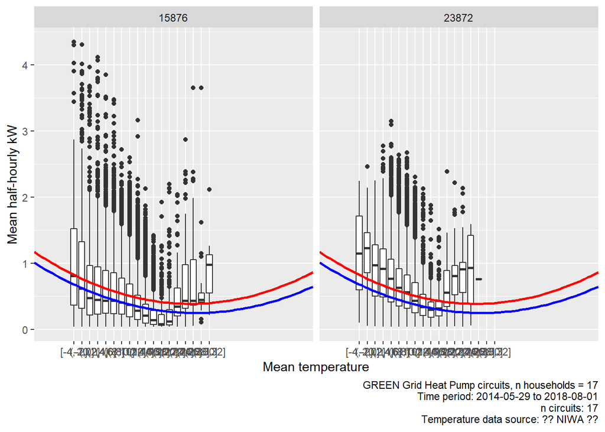

```r
ggplot2::ggplot(ejFilteredDT, mapping = aes(x = meanTemp, y = powerW/1000)) +
  geom_boxplot(aes(cut_width(meanTemp,
                             width = 2, # change the width to get 'wider' bins
                             boundary = 0)))  +
  facet_grid(. ~ location) +
  labs(caption = combinedCaption,
       x = "Mean temperature",
       y = "Mean half-hourly kW") +
  geom_smooth(modelDT, mapping = aes(temp, meanPowerWFit/1000),colour = 'red') + # mean fit
  geom_smooth(modelDT, mapping = aes(temp, medianPowerWFit/1000),colour = 'blue') # median fit
```

## 5.2 Modelling power vs temperature with consideration of location

This method does not involve taking the mean or median of the power for each binned temperature and just takes into account all points

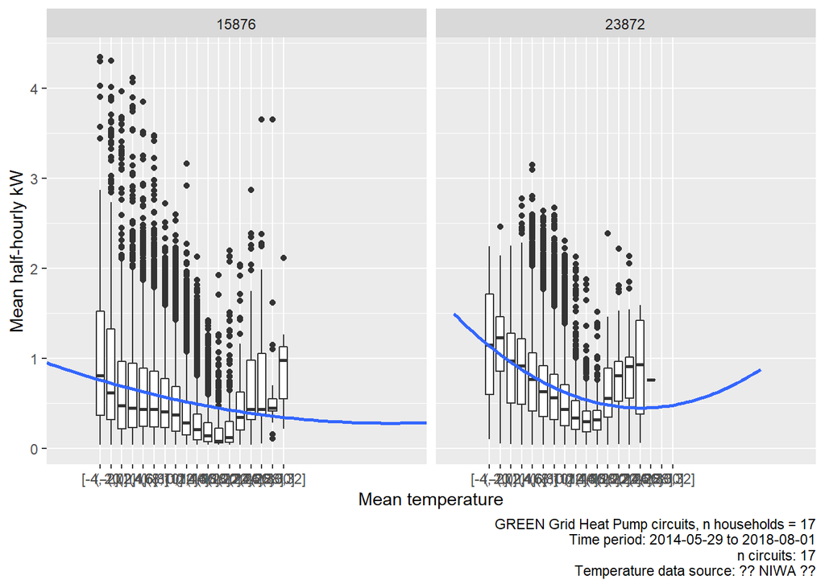

```r
ggplot2::ggplot(ejFilteredDT, mapping = aes(x = meanTemp, y = powerW/1000)) +
  geom_boxplot(aes(cut_width(meanTemp,
                             width = 2, # change the width to get 'wider' bins
                             boundary = 0)))  +
  geom_smooth(method = "lm", formula = y~poly(x,2), se = F) +
  facet_grid(. ~ location) +
  labs(caption = combinedCaption,
       x = "Mean temperature",
       y = "Mean half-hourly kW")
```

## 5.3 Modelling power vs temperature but for only a certain range

So we only want to model for U curve-y bit.

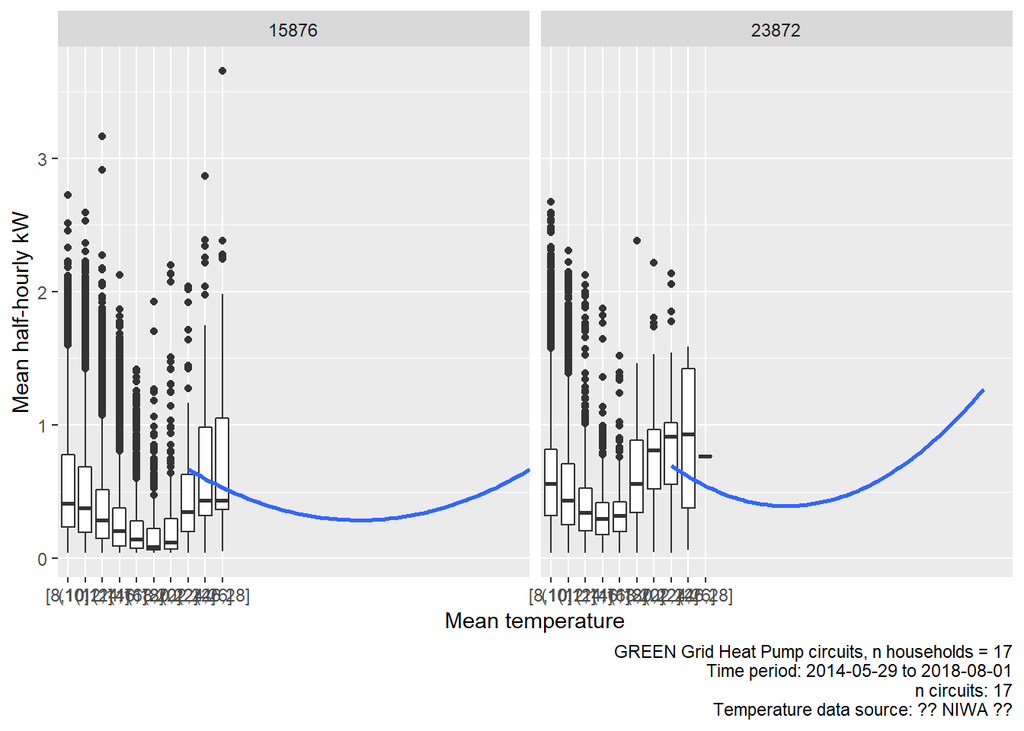

```r
# only want rows where temp is between 18 +- 10
temp = 18
ejFilteredDTRange <- ejFilteredDT[temp - 10 <= meanTemp & meanTemp < temp + 10,]

ggplot2::ggplot(ejFilteredDTRange, mapping = aes(x = meanTemp, y = powerW/1000)) +
  geom_boxplot(aes(cut_width(meanTemp,
                             width = 2, # change the width to get 'wider' bins
                             boundary = 0)))  +
  geom_smooth(method = "lm", formula = y~poly(x,2), se = F) +
  facet_grid(. ~ location) +
  labs(caption = combinedCaption,
       x = "Mean temperature",
       y = "Mean half-hourly kW")
```

# Summary of Fits

This gives the fit for all the houses.

```r
summary(lm((ejFilteredDTRange$powerW)/1000 ~ poly(ejFilteredDTRange$meanTemp,
    2)))
```

```
##
## Call:
## lm(formula = (ejFilteredDTRange$powerW)/1000 ~ poly(ejFilteredDTRange$meanTemp,
##     2))
##
## Residuals:
##     Min      1Q  Median      3Q     Max
## -0.7496 -0.2630 -0.1059  0.1570  2.8474
##
## Coefficients:
##                                        Estimate Std. Error t value
## (Intercept)                            0.476606   0.002005  237.74
## poly(ejFilteredDTRange$meanTemp, 2)1 -14.155254   0.384834  -36.78
## poly(ejFilteredDTRange$meanTemp, 2)2  14.192264   0.384834   36.88
##                                      Pr(>|t|)
## (Intercept)                            <2e-16 ***
## poly(ejFilteredDTRange$meanTemp, 2)1   <2e-16 ***
## poly(ejFilteredDTRange$meanTemp, 2)2   <2e-16 ***
## ---
## Signif. codes:  0 '***' 0.001 '**' 0.01 '*' 0.05 '.' 0.1 ' ' 1
##
## Residual standard error: 0.3848 on 36846 degrees of freedom
## Multiple R-squared:  0.06858,    Adjusted R-squared:  0.06853
## F-statistic:  1357 on 2 and 36846 DF,  p-value: < 2.2e-16
```

Fits by location

```r
summary(lm(ejFilteredDTRange[location == 15876, ]$powerW/1000 ~ poly(ejFilteredDTRange[location ==
    15876, ]$meanTemp, 2)))
```

```
##
## Call:
## lm(formula = ejFilteredDTRange[location == 15876, ]$powerW/1000 ~
##     poly(ejFilteredDTRange[location == 15876, ]$meanTemp, 2))
##
## Residuals:
##     Min      1Q  Median      3Q     Max
## -0.6302 -0.2552 -0.1254  0.1169  3.0019
##
## Coefficients:
##                                                             Estimate
## (Intercept)                                                 0.449985
## poly(ejFilteredDTRange[location == 15876, ]$meanTemp, 2)1 -13.010743
## poly(ejFilteredDTRange[location == 15876, ]$meanTemp, 2)2  10.870949
##                                                           Std. Error
## (Intercept)                                                 0.002584
## poly(ejFilteredDTRange[location == 15876, ]$meanTemp, 2)1   0.400031
## poly(ejFilteredDTRange[location == 15876, ]$meanTemp, 2)2   0.400031
##                                                           t value Pr(>|t|)
## (Intercept)                                                174.13   <2e-16
## poly(ejFilteredDTRange[location == 15876, ]$meanTemp, 2)1  -32.52   <2e-16
## poly(ejFilteredDTRange[location == 15876, ]$meanTemp, 2)2   27.18   <2e-16
##
## (Intercept)                                               ***
## poly(ejFilteredDTRange[location == 15876, ]$meanTemp, 2)1 ***
## poly(ejFilteredDTRange[location == 15876, ]$meanTemp, 2)2 ***
## ---
## Signif. codes:  0 '***' 0.001 '**' 0.01 '*' 0.05 '.' 0.1 ' ' 1
##
## Residual standard error: 0.4 on 23959 degrees of freedom
## Multiple R-squared:  0.06975,    Adjusted R-squared:  0.06967
## F-statistic: 898.2 on 2 and 23959 DF,  p-value: < 2.2e-16
```

```r
summary(lm(ejFilteredDTRange[location == 23872, ]$powerW/1000 ~ poly(ejFilteredDTRange[location ==
    23872, ]$meanTemp, 2)))
```

```
##
## Call:
## lm(formula = ejFilteredDTRange[location == 23872, ]$powerW/1000 ~
##     poly(ejFilteredDTRange[location == 23872, ]$meanTemp, 2))
##
## Residuals:
##      Min       1Q   Median       3Q      Max
## -1.00524 -0.24561 -0.06015  0.18210  2.00738
##
## Coefficients:
##                                                            Estimate
## (Intercept)                                                0.526106
## poly(ejFilteredDTRange[location == 23872, ]$meanTemp, 2)1 -3.718706
## poly(ejFilteredDTRange[location == 23872, ]$meanTemp, 2)2 10.355813
##                                                           Std. Error
## (Intercept)                                                 0.003073
## poly(ejFilteredDTRange[location == 23872, ]$meanTemp, 2)1   0.348797
## poly(ejFilteredDTRange[location == 23872, ]$meanTemp, 2)2   0.348797
##                                                           t value Pr(>|t|)
## (Intercept)                                                171.23   <2e-16
## poly(ejFilteredDTRange[location == 23872, ]$meanTemp, 2)1  -10.66   <2e-16
## poly(ejFilteredDTRange[location == 23872, ]$meanTemp, 2)2   29.69   <2e-16
##
## (Intercept)                                               ***
## poly(ejFilteredDTRange[location == 23872, ]$meanTemp, 2)1 ***
## poly(ejFilteredDTRange[location == 23872, ]$meanTemp, 2)2 ***
## ---
## Signif. codes:  0 '***' 0.001 '**' 0.01 '*' 0.05 '.' 0.1 ' ' 1
##
## Residual standard error: 0.3488 on 12884 degrees of freedom
## Multiple R-squared:  0.0717, Adjusted R-squared:  0.07156
## F-statistic: 497.6 on 2 and 12884 DF,  p-value: < 2.2e-16
```

So for some reason, the fits are not lining up with the data. I am just going to leave it for now because I can’t figure out why it is doing this. I think/hope this is why the R-squared values are very poor as well.

Say that the model fits - now what?

> Needs to include the 0 values (see discussion above)?

> If the regression model assumes independence of observations then this is violated if we have multiple observations for each house (which we do whether we just use the ‘best’ year or not…). The short-term fix would be to use robust standard errors in model reporting or maybe a fixed-effects model (?) but that might be well beyond scope of the report!

# 6 Runtime

```r
t <- proc.time() - startTime

elapsed <- t[[3]]
```

Analysis completed in 202.93 seconds ( 3.38 minutes) using knitr in [RStudio](http://www.rstudio.com) with R version 3.5.1 (2018-07-02) running on x86_64-w64-mingw32.

# 7 R packages used

> list packages used & cite

# 8 Annexes

## 8.1 Detailed statistics

Figure 8.1 shows the relationship between mean temperature and mean power for all hourly observations for all circuits colour coded by season. Smoothed fit lines have been added using `mgcv:gam()` curves due to the size of the dataset (see `?geom_smooth` and [@ggplot]).

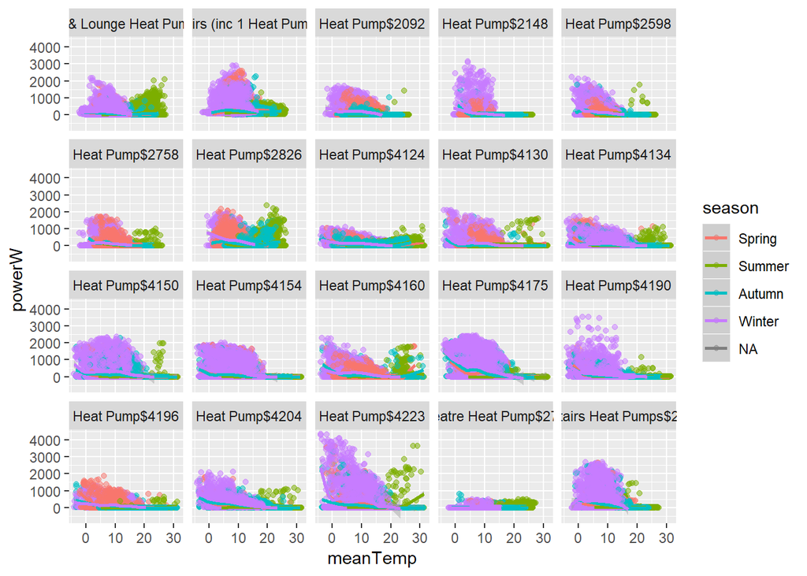

Figure 8.1: Pairs plot of temperature vs heat pump power demand for all households

```r
ggplot2::ggplot(linkedDT, aes(x = meanTemp, y = powerW, colour = season)) +
    geom_point(alpha = 0.5) + geom_smooth() + facet_wrap(. ~ circuit)
```

## 8.2 Data codebooks

### 8.2.1 Original power data (before processing)

Depending on input files choice this will vary.

- data source: emilyData
- data file: `Z:/Research Projects/GREEN Grid/Self_contained_Projects/2018_coolingEmily/archive/allHouseholds_hourly.csv.gz

```r
head(hpDT_orig)
```

```
##    V1          r_dateTime   powerW        circuit    id location
## 1:  1 2015-03-26 04:00:00  0.00000 Heat Pump$4204 rf_31    15876
## 2:  2 2015-03-26 05:00:00 33.68717 Heat Pump$4204 rf_31    15876
## 3:  3 2015-03-26 06:00:00  0.00000 Heat Pump$4204 rf_31    15876
## 4:  4 2015-03-26 07:00:00  0.00000 Heat Pump$4204 rf_31    15876
## 5:  5 2015-03-26 08:00:00  0.00000 Heat Pump$4204 rf_31    15876
## 6:  6 2015-03-26 09:00:00  0.00000 Heat Pump$4204 rf_31    15876
```

```r
skimr::skim(hpDT_orig)
```

```
## Skim summary statistics
##  n obs: 441379
##  n variables: 6
##
## -- Variable type:character -----------------------------------------------------
##    variable missing complete      n min max empty n_unique
##     circuit       0   441379 441379  14  33     0       20
##          id       0   441379 441379   5   6     0       18
##  r_dateTime       0   441379 441379  19  19     0    36583
##
## -- Variable type:integer -------------------------------------------------------
##  variable missing complete      n      mean        sd    p0      p25
##  location       0   441379 441379  19944.32   3997.39 15876  15876
##        V1       0   441379 441379 220690    127415.29     1 110345.5
##     p50      p75   p100     hist
##   23872  23872    23872 ▇▁▁▁▁▁▁▇
##  220690 331034.5 441379 ▇▇▇▇▇▇▇▇
##
## -- Variable type:numeric -------------------------------------------------------
##  variable missing complete      n  mean     sd p0 p25 p50   p75    p100
##    powerW       0   441379 441379 95.47 271.51  0   0   0 19.02 4342.47
##      hist
##  ▇▁▁▁▁▁▁▁
```

### 8.2.2 Power data (after processing)

```r
skimr::skim(hpDT)
```

```
## Skim summary statistics
##  n obs: 441379
##  n variables: 12
##
## -- Variable type:character -----------------------------------------------------
##        variable missing complete      n min max empty n_unique
##         circuit       0   441379 441379  14  33     0       20
##              id       0   441379 441379   5   6     0       18
##  r_dateTimeChar       0   441379 441379  19  19     0    36583
##
## -- Variable type:difftime ------------------------------------------------------
##  variable missing complete      n    min        max   median n_unique
##       hms       0   441379 441379 0 secs 82800 secs 12:00:00       24
##
## -- Variable type:factor --------------------------------------------------------
##  variable missing complete      n n_unique
##    season       0   441379 441379        4
##                                         top_counts ordered
##  Win: 122946, Aut: 111768, Spr: 107705, Sum: 98960   FALSE
##
## -- Variable type:integer -------------------------------------------------------
##  variable missing complete      n     mean      sd    p0   p25   p50   p75
##      hour       0   441379 441379    11.5     6.92     0     6    12    18
##  location       0   441379 441379 19944.32 3997.39 15876 15876 23872 23872
##   p100     hist
##     23 ▇▇▇▇▇▇▇▇
##  23872 ▇▁▁▁▁▁▁▇
##
## -- Variable type:numeric -------------------------------------------------------
##           variable missing complete      n  mean     sd p0 p25 p50   p75
##  ba_includeCircuit       0   441379 441379  0.88   0.33  0   1   1  1
##  ej_includeCircuit       0   441379 441379  0.8    0.4   0   1   1  1
##             powerW       0   441379 441379 95.47 271.51  0   0   0 19.02
##     p100     hist
##     1    ▁▁▁▁▁▁▁▇
##     1    ▂▁▁▁▁▁▁▇
##  4342.47 ▇▁▁▁▁▁▁▁
##
## -- Variable type:POSIXct -------------------------------------------------------
##         variable missing complete      n        min        max     median
##       r_dateTime       0   441379 441379 2014-05-28 2018-08-01 2016-04-08
##  r_dateTimeLocal       0   441379 441379 2014-05-29 2018-08-01 2016-04-09
##  n_unique
##     36583
##     36583
```

### 8.2.3 Original temperature file(s)

File 1:

```r
skimr::skim(temp15876DT)
```

```
## Skim summary statistics
##  n obs: 185459
##  n variables: 17
##
## -- Variable type:character -----------------------------------------------------
##       variable missing complete      n min max empty n_unique
##     Date(NZST)       0   185459 185459  16  16     0   185455
##           Freq       0   185459 185459   1   1     0        1
##    Period(Hrs)       0   185459 185459   1   1     0        2
##  Period(Hrs).1       0   185459 185459   1   1     0        2
##  Period(Hrs).2       0   185459 185459   1   1     0        2
##  Period(Hrs).3       0   185459 185459   1   1     0        2
##      RHmean(%)       0   185459 185459   1   3     0       88
##       Tgmin(C)       0   185459 185459   1   4     0      569
##        Tmax(C)       0   185459 185459   1   4     0      385
##       Tmean(C)       0   185459 185459   1   5     0      382
##        Tmin(C)       0   185459 185459   1   5     0      378
##
## -- Variable type:difftime ------------------------------------------------------
##  variable missing complete      n    min        max     median n_unique
##       hms      21   185438 185459 0 secs 82800 secs 43200 secs       24
##
## -- Variable type:factor --------------------------------------------------------
##  variable missing complete      n n_unique
##    season       0   185459 185459        4
##                                      top_counts ordered
##  Spr: 47102, Win: 46360, Aut: 46082, Sum: 45915   FALSE
##
## -- Variable type:integer -------------------------------------------------------
##  variable missing complete      n  mean sd    p0   p25   p50   p75  p100
##  location       0   185459 185459 15876  0 15876 15876 15876 15876 15876
##   Station       0   185459 185459 15876  0 15876 15876 15876 15876 15876
##      hist
##  ▁▁▁▇▁▁▁▁
##  ▁▁▁▇▁▁▁▁
##
## -- Variable type:POSIXct -------------------------------------------------------
##         variable missing complete      n        min        max     median
##       r_dateTime      21   185438 185459 1997-09-11 2019-01-06 2008-05-19
##  r_dateTimeLocal      21   185438 185459 1997-09-11 2019-01-06 2008-05-19
##  n_unique
##    185434
##    185434
```

File 2:

```r
skimr::skim(temp23872DT)
```

```
## Skim summary statistics
##  n obs: 143260
##  n variables: 17
##
## -- Variable type:character -----------------------------------------------------
##       variable missing complete      n min max empty n_unique
##     Date(NZST)       0   143260 143260  16  16     0   139010
##           Freq       0   143260 143260   1   1     0        1
##    Period(Hrs)       0   143260 143260   1   1     0        2
##  Period(Hrs).1       0   143260 143260   1   1     0        2
##  Period(Hrs).2       0   143260 143260   1   1     0        2
##  Period(Hrs).3       0   143260 143260   1   1     0        2
##      RHmean(%)       0   143260 143260   1   3     0       85
##       Tgmin(C)       0   143260 143260   1   4     0      511
##        Tmax(C)       0   143260 143260   1   4     0      307
##       Tmean(C)       0   143260 143260   1   4     0      303
##        Tmin(C)       0   143260 143260   1   4     0      302
##
## -- Variable type:difftime ------------------------------------------------------
##  variable missing complete      n    min        max     median n_unique
##       hms      16   143244 143260 0 secs 82800 secs 43200 secs       24
##
## -- Variable type:factor --------------------------------------------------------
##  variable missing complete      n n_unique
##    season       0   143260 143260        4
##                                      top_counts ordered
##  Aut: 36423, Sum: 36244, Win: 36023, Spr: 34570   FALSE
##
## -- Variable type:integer -------------------------------------------------------
##  variable missing complete      n  mean sd    p0   p25   p50   p75  p100
##  location       0   143260 143260 23872  0 23872 23872 23872 23872 23872
##   Station       0   143260 143260 23872  0 23872 23872 23872 23872 23872
##      hist
##  ▁▁▁▇▁▁▁▁
##  ▁▁▁▇▁▁▁▁
##
## -- Variable type:POSIXct -------------------------------------------------------
##         variable missing complete      n        min        max     median
##       r_dateTime      16   143244 143260 2002-12-06 2019-01-06 2010-09-02
##  r_dateTimeLocal      16   143244 143260 2002-12-06 2019-01-06 2010-09-02
##  n_unique
##    138994
##    138994
```

Combined file:

```r
skimr::skim(tempBothDT)
```

```
## Skim summary statistics
##  n obs: 324465
##  n variables: 12
##
## -- Variable type:character -----------------------------------------------------
##    variable missing complete      n min max empty n_unique
##  r_dateTime      37   324428 324465  19  19     0   186732
##      source       0   324465 324465  21  21     0        1
##
## -- Variable type:difftime ------------------------------------------------------
##  variable missing complete      n    min        max     median n_unique
##       hms      37   324428 324465 0 secs 82800 secs 43200 secs       24
##
## -- Variable type:factor --------------------------------------------------------
##  variable missing complete      n n_unique
##    season       0   324465 324465        4
##                                      top_counts ordered
##  Spr: 81672, Win: 81298, Sum: 81200, Aut: 80295   FALSE
##
## -- Variable type:integer -------------------------------------------------------
##    variable missing complete      n     mean      sd    p0   p25   p50
##    location       0   324465 324465 19301.71 3956.83 15876 15876 15876
##  location.1       0   324465 324465 19301.71 3956.83 15876 15876 15876
##    p75  p100     hist
##  23872 23872 ▇▁▁▁▁▁▁▆
##  23872 23872 ▇▁▁▁▁▁▁▆
##
## -- Variable type:numeric -------------------------------------------------------
##  variable missing complete      n    mean   sd     p0    p25    p50    p75
##  meanTemp     634   323831 324465   12.63 5.3   -10      9.1   12.6   16.3
##    Tmax_C     503   323962 324465   13.26 5.33   -9.5    9.7   13.2   16.9
##   Tmean_C     634   323831 324465   12.63 5.3   -10      9.1   12.6   16.3
##    Tmin_C     577   323888 324465   12.02 5.29  -12.2    8.5   12     15.7
##      year      37   324428 324465 2008.96 5.69 1997   2004   2009   2014
##    p100     hist
##    35.6 ▁▁▃▇▇▂▁▁
##    36.4 ▁▁▃▇▇▃▁▁
##    35.6 ▁▁▃▇▇▂▁▁
##    34.2 ▁▁▂▇▇▃▁▁
##  2019   ▃▅▇▇▆▇▇▅
##
## -- Variable type:POSIXct -------------------------------------------------------
##         variable missing complete      n        min        max     median
##  r_dateTimeLocal      37   324428 324465 1997-09-11 2019-01-06 2009-08-24
##  n_unique
##    186732
```

# 9 References